# Fraudulent Firm : Regression & Classification

This dataset is taken from research to help the auditors by building a classification model that can predict the fraudulent firm on the basis of the present and historical risk factors. The information about the sectors and the counts of firms are listed respectively as Irrigation (114), Public Health (77), Buildings and Roads (82), Forest (70), Corporate (47), Animal Husbandry (95), Communication (1), Electrical (4), Land (5), Science and Technology (3), Tourism (1), Fisheries (41), Industries (37), Agriculture (200).

There are two CSV files Audit_Risk and Trial. We have considered `Audit_Risk` as target column for regression tasks, and `Risk` as the target column for classification tasks.

```python
import numpy as np
import pandas as pd
import matplotlib.pyplot as plt
```

```python
audit_risk = pd.read_csv("audit_risk.csv")
trial = pd.read_csv("trial.csv")
```

```python
display(audit_risk.shape)
display(audit_risk.head())
display(trial.shape)
display(trial.head())
```

```
(776, 27)
```

|  | Sector_score | LOCATION_ID | PARA_A | Score_A | Risk_A | PARA_B | Score_B | Risk_B | TOTAL | numbers | ... | RiSk_E | History | Prob | Risk_F | Score | Inherent_Risk | CONTROL_RISK | Detection_Risk | Audit_Risk | Risk |
| --- | --- | --- | --- | --- | --- | --- | --- | --- | --- | --- | --- | --- | --- | --- | --- | --- | --- | --- | --- | --- | --- |
| 0 | 3.89 | 23 | 4.18 | 0.6 | 2.508 | 2.50 | 0.2 | 0.500 | 6.68 | 5.0 | ... | 0.4 | 0 | 0.2 | 0.0 | 2.4 | 8.574 | 0.4 | 0.5 | 1.7148 | 1 |
| 1 | 3.89 | 6 | 0.00 | 0.2 | 0.000 | 4.83 | 0.2 | 0.966 | 4.83 | 5.0 | ... | 0.4 | 0 | 0.2 | 0.0 | 2.0 | 2.554 | 0.4 | 0.5 | 0.5108 | 0 |
| 2 | 3.89 | 6 | 0.51 | 0.2 | 0.102 | 0.23 | 0.2 | 0.046 | 0.74 | 5.0 | ... | 0.4 | 0 | 0.2 | 0.0 | 2.0 | 1.548 | 0.4 | 0.5 | 0.3096 | 0 |
| 3 | 3.89 | 6 | 0.00 | 0.2 | 0.000 | 10.80 | 0.6 | 6.480 | 10.80 | 6.0 | ... | 0.4 | 0 | 0.2 | 0.0 | 4.4 | 17.530 | 0.4 | 0.5 | 3.5060 | 1 |
| 4 | 3.89 | 6 | 0.00 | 0.2 | 0.000 | 0.08 | 0.2 | 0.016 | 0.08 | 5.0 | ... | 0.4 | 0 | 0.2 | 0.0 | 2.0 | 1.416 | 0.4 | 0.5 | 0.2832 | 0 |

5 rows × 27 columns

```
(776, 18)
```

|  | Sector_score | LOCATION_ID | PARA_A | SCORE_A | PARA_B | SCORE_B | TOTAL | numbers | Marks | Money_Value | MONEY_Marks | District | Loss | LOSS_SCORE | History | History_score | Score | Risk |
| --- | --- | --- | --- | --- | --- | --- | --- | --- | --- | --- | --- | --- | --- | --- | --- | --- | --- | --- |
| 0 | 3.89 | 23 | 4.18 | 6 | 2.50 | 2 | 6.68 | 5.0 | 2 | 3.38 | 2 | 2 | 0 | 2 | 0 | 2 | 2.4 | 1 |
| 1 | 3.89 | 6 | 0.00 | 2 | 4.83 | 2 | 4.83 | 5.0 | 2 | 0.94 | 2 | 2 | 0 | 2 | 0 | 2 | 2.0 | 0 |
| 2 | 3.89 | 6 | 0.51 | 2 | 0.23 | 2 | 0.74 | 5.0 | 2 | 0.00 | 2 | 2 | 0 | 2 | 0 | 2 | 2.0 | 0 |
| 3 | 3.89 | 6 | 0.00 | 2 | 10.80 | 6 | 10.80 | 6.0 | 6 | 11.75 | 6 | 2 | 0 | 2 | 0 | 2 | 4.4 | 1 |
| 4 | 3.89 | 6 | 0.00 | 2 | 0.08 | 2 | 0.08 | 5.0 | 2 | 0.00 | 2 | 2 | 0 | 2 | 0 | 2 | 2.0 | 0 |

### Checking Missing Values

Here, we are checking missing values in DataFrames Audit_Risk and Risk respectively. We can clearly see that there is only one missing value present in the `Money_Value` column in both DataFrames.

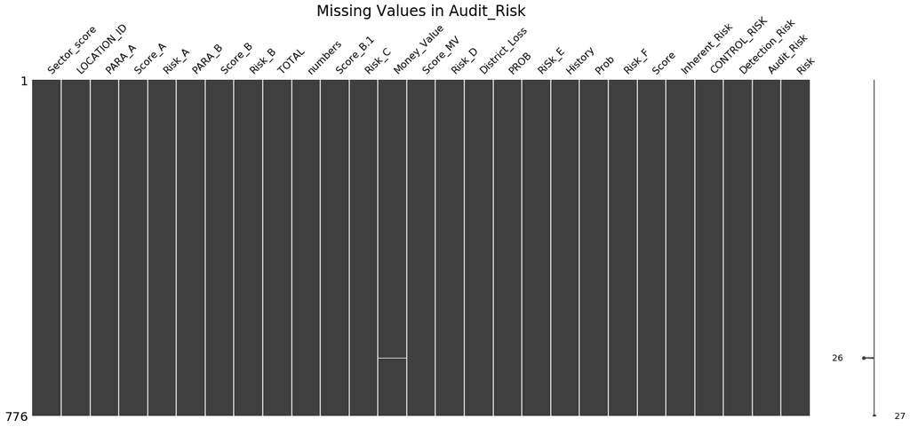

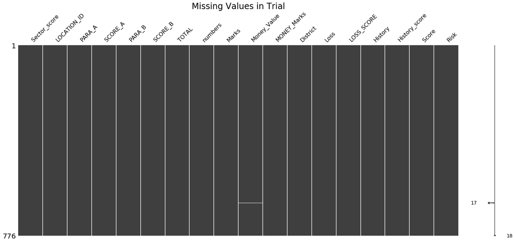

```python
import missingno as msno

msno.matrix(audit_risk)
plt.title("Missing Values in Audit_Risk",y=1.18, fontsize=24)
msno.matrix(trial)
plt.title("Missing Values in Trial",y=1.18, fontsize=24)
```

### Number of Unique values in each column

As we have to merge two dataframes for regression and classification task so here we are looking for number of unique values in each column so we can merge dataframes using that common column.

Clearly, there is no column which has a number of unique value equals to our number of records of the dataframe i.e. 776 hence we can not merge two dataframes just using single column and we have to think of combining multiple columns while merging the dataframes.

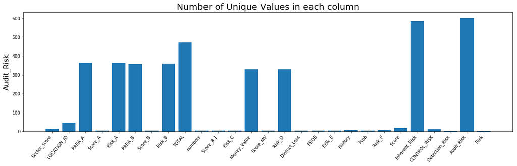

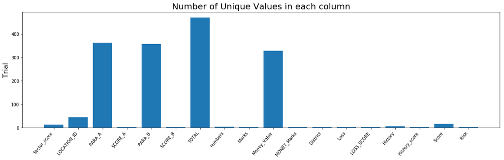

```python
y_audit_risk=[]
x_audit_risk=[]
for i in range(len(audit_risk.nunique().index)):
    y_audit_risk.append(audit_risk.nunique().index[i])
    x_audit_risk.append(audit_risk.nunique()[i])

y_trial=[]
x_trial=[]
for i in range(len(trial.nunique().index)):
    y_trial.append(trial.nunique().index[i])
    x_trial.append(trial.nunique()[i])

plt.figure(figsize=(20,5))

plt.bar(y_audit_risk,x_audit_risk, align='center', alpha=1)
plt.ylabel('Audit_Risk', Fontsize= 16)
plt.title('Number of Unique Values in each column',fontsize=20)
plt.xticks(rotation=50, ha="right")

plt.show()

plt.figure(figsize=(20,5))

plt.bar(y_trial,x_trial, align='center', alpha=1)
plt.ylabel('Trial', Fontsize= 16)
plt.title('Number of Unique Values in each column',fontsize=20)
plt.xticks(rotation=50, ha="right")

plt.show()
```

```python
audit_risk.columns & trial.columns
```

```
Index(['Sector_score', 'LOCATION_ID', 'PARA_A', 'PARA_B', 'TOTAL', 'numbers',
       'Money_Value', 'History', 'Score', 'Risk'],
      dtype='object')
```

### Find Duplicate Rows

```python
audit_risk[audit_risk.duplicated() == True]
```

|  | Sector_score | LOCATION_ID | PARA_A | Score_A | Risk_A | PARA_B | Score_B | Risk_B | TOTAL | numbers | ... | RiSk_E | History | Prob | Risk_F | Score | Inherent_Risk | CONTROL_RISK | Detection_Risk | Audit_Risk | Risk |
| --- | --- | --- | --- | --- | --- | --- | --- | --- | --- | --- | --- | --- | --- | --- | --- | --- | --- | --- | --- | --- | --- |
| 265 | 2.72 | 15 | 0.00 | 0.2 | 0.000 | 0.0 | 0.2 | 0.00 | 0.00 | 5.0 | ... | 0.4 | 0 | 0.2 | 0.0 | 2.0 | 1.400 | 0.4 | 0.5 | 0.2800 | 0 |
| 474 | 1.85 | 16 | 0.00 | 0.2 | 0.000 | 0.0 | 0.2 | 0.00 | 0.00 | 5.0 | ... | 0.4 | 0 | 0.2 | 0.0 | 2.0 | 1.400 | 0.4 | 0.5 | 0.2800 | 0 |
| 600 | 55.57 | 8 | 0.00 | 0.2 | 0.000 | 0.0 | 0.2 | 0.00 | 0.00 | 5.0 | ... | 0.4 | 0 | 0.2 | 0.0 | 2.0 | 1.400 | 0.4 | 0.5 | 0.2800 | 0 |
| 659 | 55.57 | 5 | 0.00 | 0.2 | 0.000 | 0.0 | 0.2 | 0.00 | 0.00 | 5.0 | ... | 0.4 | 0 | 0.2 | 0.0 | 2.0 | 1.400 | 0.4 | 0.5 | 0.2800 | 0 |
| 679 | 55.57 | 9 | 0.00 | 0.2 | 0.000 | 0.0 | 0.2 | 0.00 | 0.00 | 5.0 | ... | 0.4 | 0 | 0.2 | 0.0 | 2.0 | 1.400 | 0.4 | 0.5 | 0.2800 | 0 |
| 695 | 55.57 | 12 | 0.00 | 0.2 | 0.000 | 0.0 | 0.2 | 0.00 | 0.00 | 5.0 | ... | 0.4 | 0 | 0.2 | 0.0 | 2.0 | 1.400 | 0.4 | 0.5 | 0.2800 | 0 |
| 696 | 55.57 | 12 | 0.00 | 0.2 | 0.000 | 0.0 | 0.2 | 0.00 | 0.00 | 5.0 | ... | 0.4 | 0 | 0.2 | 0.0 | 2.0 | 1.400 | 0.4 | 0.5 | 0.2800 | 0 |
| 704 | 55.57 | 8 | 0.00 | 0.2 | 0.000 | 0.0 | 0.2 | 0.00 | 0.00 | 5.0 | ... | 0.4 | 0 | 0.2 | 0.0 | 2.0 | 1.400 | 0.4 | 0.5 | 0.2800 | 0 |
| 715 | 55.57 | 27 | 0.00 | 0.2 | 0.000 | 0.0 | 0.2 | 0.00 | 0.00 | 5.0 | ... | 0.4 | 0 | 0.2 | 0.0 | 2.0 | 1.400 | 0.4 | 0.5 | 0.2800 | 0 |
| 716 | 55.57 | 2 | 0.00 | 0.2 | 0.000 | 0.0 | 0.2 | 0.00 | 0.00 | 5.0 | ... | 1.2 | 0 | 0.2 | 0.0 | 2.4 | 2.200 | 1.2 | 0.5 | 1.3200 | 1 |
| 742 | 55.57 | 15 | 0.00 | 0.2 | 0.000 | 0.0 | 0.2 | 0.00 | 0.00 | 5.0 | ... | 0.4 | 0 | 0.2 | 0.0 | 2.0 | 1.400 | 0.4 | 0.5 | 0.2800 | 0 |
| 761 | 55.57 | 12 | 0.00 | 0.2 | 0.000 | 0.0 | 0.2 | 0.00 | 0.00 | 5.0 | ... | 0.4 | 0 | 0.2 | 0.0 | 2.0 | 1.400 | 0.4 | 0.5 | 0.2800 | 0 |
| 771 | 55.57 | 9 | 0.49 | 0.2 | 0.098 | 0.4 | 0.2 | 0.08 | 0.89 | 5.0 | ... | 0.4 | 0 | 0.2 | 0.0 | 2.0 | 1.578 | 0.4 | 0.5 | 0.3156 | 0 |

13 rows × 27 columns

```python
trial[trial.duplicated() == True]
```

|  | Sector_score | LOCATION_ID | PARA_A | SCORE_A | PARA_B | SCORE_B | TOTAL | numbers | Marks | Money_Value | MONEY_Marks | District | Loss | LOSS_SCORE | History | History_score | Score | Risk |
| --- | --- | --- | --- | --- | --- | --- | --- | --- | --- | --- | --- | --- | --- | --- | --- | --- | --- | --- |
| 265 | 2.72 | 15 | 0.00 | 2 | 0.0 | 2 | 0.00 | 5.0 | 2 | 0.0 | 2 | 2 | 0 | 2 | 0 | 2 | 2.0 | 0 |
| 474 | 1.85 | 16 | 0.00 | 2 | 0.0 | 2 | 0.00 | 5.0 | 2 | 0.0 | 2 | 2 | 0 | 2 | 0 | 2 | 2.0 | 0 |
| 600 | 55.57 | 8 | 0.00 | 2 | 0.0 | 2 | 0.00 | 5.0 | 2 | 0.0 | 2 | 2 | 0 | 2 | 0 | 2 | 2.0 | 0 |
| 659 | 55.57 | 5 | 0.00 | 2 | 0.0 | 2 | 0.00 | 5.0 | 2 | 0.0 | 2 | 2 | 0 | 2 | 0 | 2 | 2.0 | 0 |
| 679 | 55.57 | 9 | 0.00 | 2 | 0.0 | 2 | 0.00 | 5.0 | 2 | 0.0 | 2 | 2 | 0 | 2 | 0 | 2 | 2.0 | 0 |
| 695 | 55.57 | 12 | 0.00 | 2 | 0.0 | 2 | 0.00 | 5.0 | 2 | 0.0 | 2 | 2 | 0 | 2 | 0 | 2 | 2.0 | 0 |
| 696 | 55.57 | 12 | 0.00 | 2 | 0.0 | 2 | 0.00 | 5.0 | 2 | 0.0 | 2 | 2 | 0 | 2 | 0 | 2 | 2.0 | 0 |
| 704 | 55.57 | 8 | 0.00 | 2 | 0.0 | 2 | 0.00 | 5.0 | 2 | 0.0 | 2 | 2 | 0 | 2 | 0 | 2 | 2.0 | 0 |
| 715 | 55.57 | 27 | 0.00 | 2 | 0.0 | 2 | 0.00 | 5.0 | 2 | 0.0 | 2 | 2 | 0 | 2 | 0 | 2 | 2.0 | 0 |
| 716 | 55.57 | 2 | 0.00 | 2 | 0.0 | 2 | 0.00 | 5.0 | 2 | 0.0 | 2 | 6 | 0 | 2 | 0 | 2 | 2.4 | 1 |
| 742 | 55.57 | 15 | 0.00 | 2 | 0.0 | 2 | 0.00 | 5.0 | 2 | 0.0 | 2 | 2 | 0 | 2 | 0 | 2 | 2.0 | 0 |
| 761 | 55.57 | 12 | 0.00 | 2 | 0.0 | 2 | 0.00 | 5.0 | 2 | 0.0 | 2 | 2 | 0 | 2 | 0 | 2 | 2.0 | 0 |
| 771 | 55.57 | 9 | 0.49 | 2 | 0.4 | 2 | 0.89 | 5.0 | 2 | 0.0 | 2 | 2 | 0 | 2 | 0 | 2 | 2.0 | 0 |

### Remove Duplicate Rows

While training a supervised learning algorithm, the usual assumptions are that:

1. Data points are independent and identically distributed
2. Training and testing data is sampled from the same distribution

In light of these assumptions, we are removing duplicate records from both daframes.

```python
audit_risk=audit_risk.drop_duplicates()
display(audit_risk.shape)
trial=trial.drop_duplicates()
display(trial.shape)
```

```
(763, 27)
```

```
(763, 18)
```

### Create Unique column to merge two dataframes

Here, We have tried a different combination of common columns of both data frames to create a unique column which gives `763` unique values so we can merge two data frames using that common column.

Finally after some trial and error combination of five columns i.e `Money_Value`,`TOTAL`,`LOCATION_ID`,`Sector_score` and `Score` gave us `763` unique values for both columns. so We have created one column each named `Merge_audit` and `Merge_trial` in Audit_Risk and Dataframe respectively.

```python
audit_risk['Merge_audit']= audit_risk['Money_Value'].astype(str) + '-' + audit_risk['TOTAL'].astype(str) + '-' + audit_risk['LOCATION_ID'].astype(str) + '-' + audit_risk['Sector_score'].astype(str) + '-' + audit_risk['Score'].astype(str)
audit_risk['Merge_audit'].nunique()
```

```
763
```

```python
trial['Merge_trial']= trial['Money_Value'].astype(str) + '-' + trial['TOTAL'].astype(str) + '-' + trial['LOCATION_ID'].astype(str) + '-' + trial['Sector_score'].astype(str) + '-' + trial['Score'].astype(str)
trial['Merge_trial'].nunique()
```

```
763
```

## Merging dataframes

```python
cols_to_use1 = trial.columns & audit_risk.columns
cols_to_use1
```

```
Index(['Sector_score', 'LOCATION_ID', 'PARA_A', 'PARA_B', 'TOTAL', 'numbers',
       'Money_Value', 'History', 'Score', 'Risk'],
      dtype='object')
```

```python
trl_columns = trial.columns.difference(cols_to_use1)
audit = pd.merge(audit_risk, trial[trl_columns], left_on='Merge_audit', right_on = 'Merge_trial', how='inner')
audit.shape
```

```
(763, 37)
```

```python
audit.columns
```

```
Index(['Sector_score', 'LOCATION_ID', 'PARA_A', 'Score_A', 'Risk_A', 'PARA_B',
       'Score_B', 'Risk_B', 'TOTAL', 'numbers', 'Score_B.1', 'Risk_C',
       'Money_Value', 'Score_MV', 'Risk_D', 'District_Loss', 'PROB', 'RiSk_E',
       'History', 'Prob', 'Risk_F', 'Score', 'Inherent_Risk', 'CONTROL_RISK',
       'Detection_Risk', 'Audit_Risk', 'Risk', 'Merge_audit', 'District',
       'History_score', 'LOSS_SCORE', 'Loss', 'MONEY_Marks', 'Marks',
       'Merge_trial', 'SCORE_A', 'SCORE_B'],
      dtype='object')
```

We have created Merge_audit and Merge_trial columns just to merge data frames and Detection_Risk has the same value across all observations.

Hence, we are dropping Merge_Audit, Merge_trial, and Detection_Risk.

```python
audit = audit.drop(['Merge_audit','Merge_trial', 'Detection_Risk'], axis = 1)
audit.shape
```

```
(763, 34)
```

## Correlations of each features in Dataset

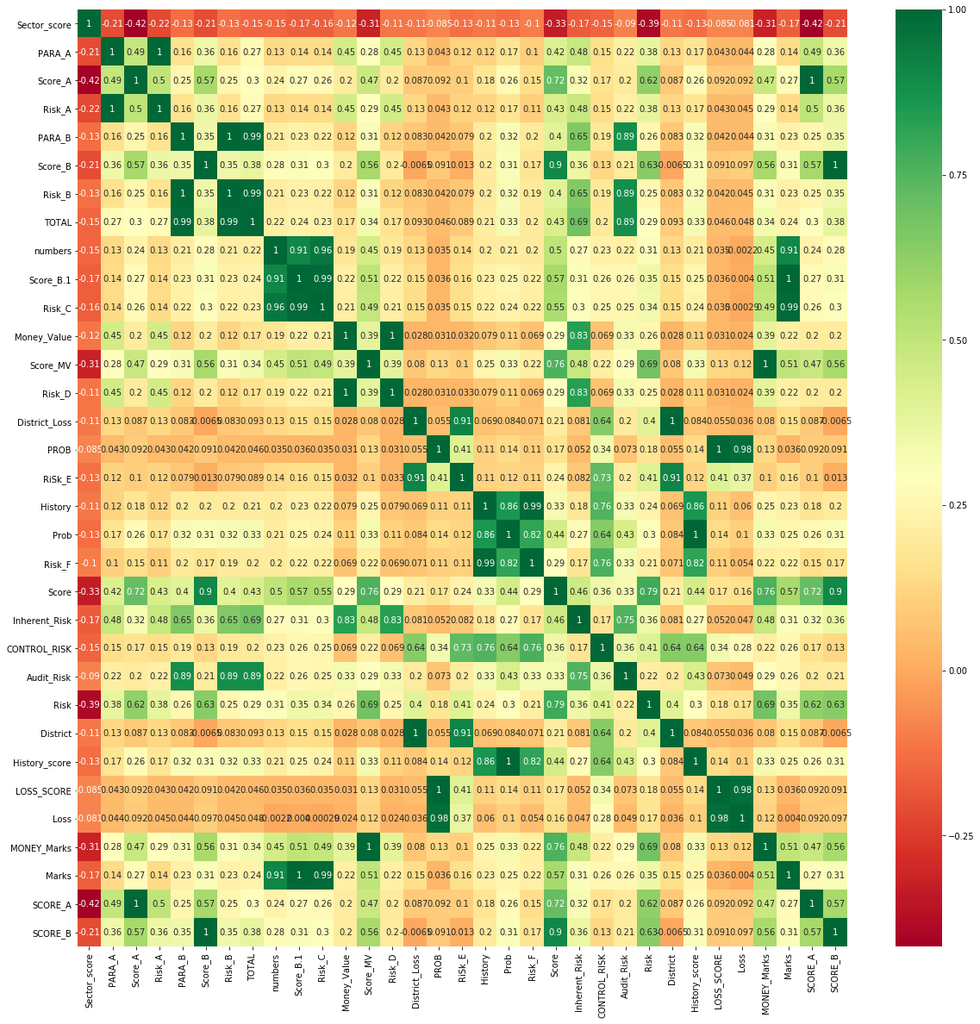

```python
import seaborn as sns

#get correlations of each features in dataset
corrmat = audit.corr()
top_corr_features = corrmat.index
plt.figure(figsize=(20,20))
#plot heat map
g=sns.heatmap(audit[top_corr_features].corr(),annot=True,cmap="RdYlGn")
```

After looking at the correlation map, columns `Risk_A`, `Risk_B`, `MONEY_Marks`, `Score_B.1`, `District`, `Prob`, `PROB`, `SCORE_A`, `SCORE_B` are correlated `PARA_A`, `PARA_B`, `Score_MV`, `Marks`, `District_Loss`, `History_score`, `LOSS_SCORE`, `Score_A`, `Score_B` with value of 1 respectively.

So We are dropping these columns too.

```python
audit =  audit.drop(['Risk_A','Risk_B','MONEY_Marks','Risk_C','Score_B.1','Risk_F','District','Prob','PROB','Risk_D','SCORE_A','SCORE_B'],axis=1)
```

We can see there are three `LOCATION_ID`s to those numeric values are not assigned so we are assigning three missing numeric values 10,26 and 45 to those `LOCATION_ID`s.

```python
print(audit['LOCATION_ID'].unique())
```

```
['23' '6' '7' '8' '13' '37' '24' '3' '4' '14' '5' '20' '19' '21' '22' '9'
 '11' '12' '29' '30' '38' '31' '2' '32' '16' '33' '15' '36' '34' '18' '25'
 '39' '27' '35' '40' '41' '42' '1' '28' 'LOHARU' 'NUH' 'SAFIDON' '43' '44'
 '17']
```

```python
audit['LOCATION_ID']=audit['LOCATION_ID'].replace('LOHARU',10)
audit['LOCATION_ID']=audit['LOCATION_ID'].replace('NUH',26)
audit['LOCATION_ID']=audit['LOCATION_ID'].replace('SAFIDON',45)

audit['LOCATION_ID']=(audit['LOCATION_ID']).astype(float)
```

```python
for i in range(len(audit.columns)):
    audit[audit.columns[i]]=audit[audit.columns[i]].astype(float)
```

### Feature Distribution

Now, we are looking at the overall distribution of the dataset to get a glimpse of skewness of the data across all columns. we can see there are a significant amount of outliers for columns `PARA_B`, `Money_Value` and `Inherent_Risk`.

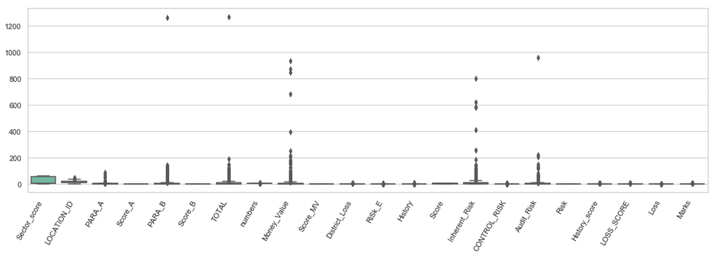

```python
plt.figure(figsize=(18,5))

sns.set(style="whitegrid")
ax = sns.boxplot(data=audit, orient="v", palette="Set2")
plt.xticks(rotation=60, ha="right")
```

Now, we are plotting to scatter plot for above-mentioned columns with respect to our target variable `Audit_Risk`. we can clearly see that there are outliers for those columns. So now we are plotting to scatter plot between these features with respect to our target variable `Audit_Risk` and we can confirm that there are outliers for those columns.

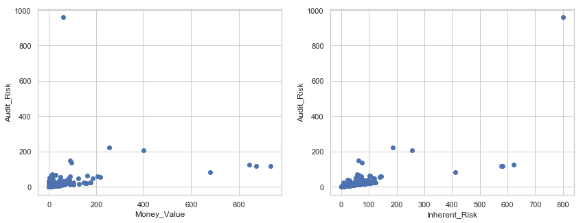

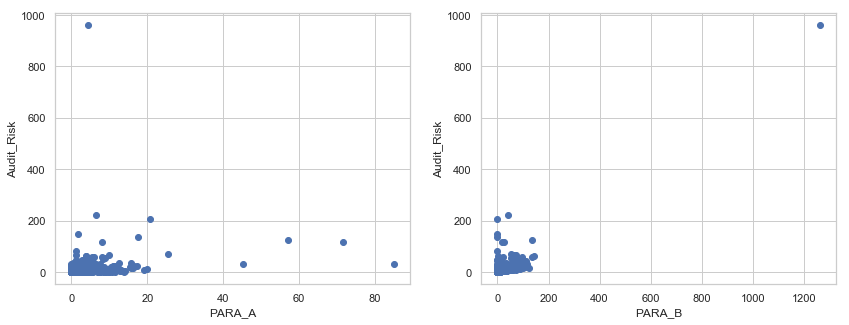

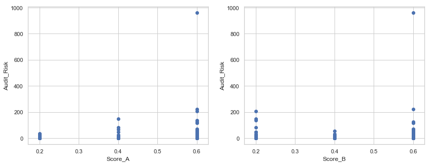

```python
plt.figure(figsize=(14,5))

plt.subplot(1,2,1)
plt.scatter(audit['Money_Value'], audit['Audit_Risk'])
plt.ylabel('Audit_Risk')
plt.xlabel('Money_Value')

plt.subplot(1,2,2)
plt.scatter(audit['Inherent_Risk'], audit['Audit_Risk'])
plt.ylabel('Audit_Risk')
plt.xlabel('Inherent_Risk')
plt.show()

plt.figure(figsize=(14,5))

plt.subplot(1,2,1)
plt.scatter(audit['PARA_A'], audit['Audit_Risk'])
plt.ylabel('Audit_Risk')
plt.xlabel('PARA_A')

plt.subplot(1,2,2)
plt.scatter(audit['PARA_B'], audit['Audit_Risk'])
plt.ylabel('Audit_Risk')
plt.xlabel('PARA_B')

plt.show()

plt.figure(figsize=(14,5))

plt.subplot(1,2,1)
plt.scatter(audit['Score_A'], audit['Audit_Risk'])
plt.ylabel('Audit_Risk')
plt.xlabel('Score_A')

plt.subplot(1,2,2)
plt.scatter(audit['Score_B'], audit['Audit_Risk'])
plt.ylabel('Audit_Risk')
plt.xlabel('Score_B')

plt.show()
```

## Remove Outliers

First, we tried to impute outliers with a median value of that particular feature but because of highly skewed nature of the data, the model was not fitting the properly to data so we have decided to remove the outlier with an intent that we remove as less data as possible with high accuracy of the models.

```python
Q1 = audit.quantile(0.25)
Q3 = audit.quantile(0.75)

IQR = Q3 - Q1
```

```python
mask = ((audit[['PARA_A', 'Score_A', 'PARA_B', 'Score_B','Inherent_Risk','Money_Value']] < (Q1 - 30 * IQR))
        | (audit[['PARA_A', 'Score_A', 'PARA_B', 'Score_B','Inherent_Risk','Money_Value']] > (Q3 + 30 * IQR)))

audit[mask]= np.NaN
```

```python
audit.isnull().sum()
```

```
Sector_score     0
LOCATION_ID      0
PARA_A           2
Score_A          0
PARA_B           3
Score_B          0
TOTAL            0
numbers          0
Money_Value      9
Score_MV         0
District_Loss    0
RiSk_E           0
History          0
Score            0
Inherent_Risk    5
CONTROL_RISK     0
Audit_Risk       0
Risk             0
History_score    0
LOSS_SCORE       0
Loss             0
Marks            0
dtype: int64
```

```python
audit = audit.dropna()
```

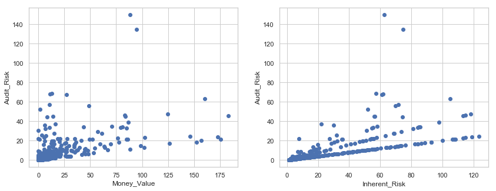

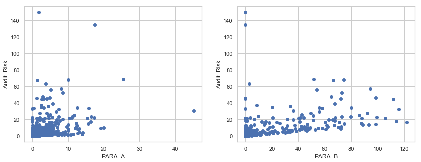

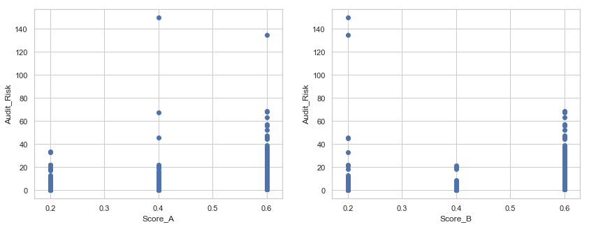

```python
plt.figure(figsize=(14,5))

plt.subplot(1,2,1)
plt.scatter(audit['Money_Value'], audit['Audit_Risk'])
plt.ylabel('Audit_Risk')
plt.xlabel('Money_Value')

plt.subplot(1,2,2)
plt.scatter(audit['Inherent_Risk'], audit['Audit_Risk'])
plt.ylabel('Audit_Risk')
plt.xlabel('Inherent_Risk')
plt.show()

plt.figure(figsize=(14,5))

plt.subplot(1,2,1)
plt.scatter(audit['PARA_A'], audit['Audit_Risk'])
plt.ylabel('Audit_Risk')
plt.xlabel('PARA_A')

plt.subplot(1,2,2)
plt.scatter(audit['PARA_B'], audit['Audit_Risk'])
plt.ylabel('Audit_Risk')
plt.xlabel('PARA_B')

plt.show()

plt.figure(figsize=(14,5))

plt.subplot(1,2,1)
plt.scatter(audit['Score_A'], audit['Audit_Risk'])
plt.ylabel('Audit_Risk')
plt.xlabel('Score_A')

plt.subplot(1,2,2)
plt.scatter(audit['Score_B'], audit['Audit_Risk'])
plt.ylabel('Audit_Risk')
plt.xlabel('Score_B')

plt.show()
```

```python
audit.shape
```

```
(750, 22)
```

### Type of Scaling

Let us check for the distribution of the datapoints of all features:

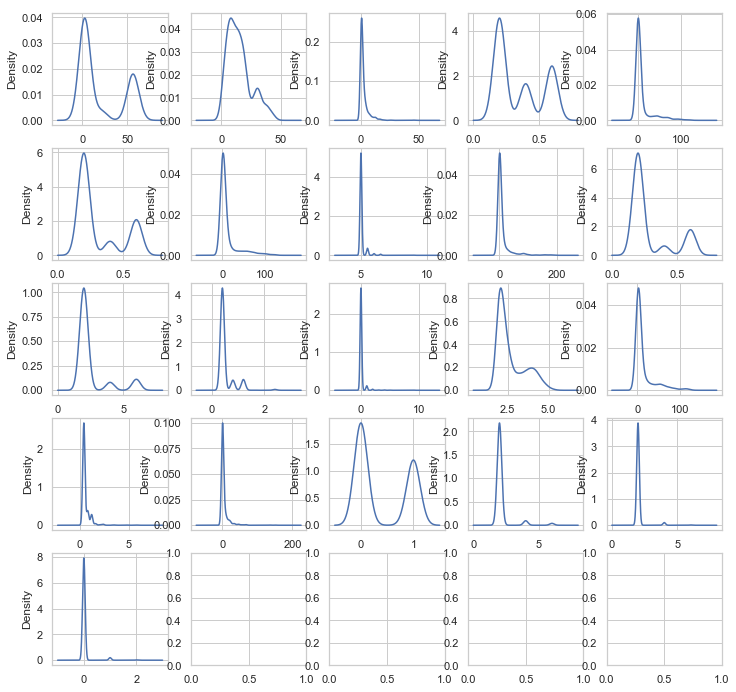

```python
fig, axes = plt.subplots(5,5, figsize=(12, 12))
j=0
for i in range(0,21):
    audit.iloc[:,i].plot.kde(ax=axes[j//5,j%5])
    j= j+1
```

Standard scaler is used when the datapoints are having a guassian distribution i.e. most of the datapoitns lie around the mean of that feature.

From the above graph, we can say that the datapoints of the feature may not have a gaussian distribution as the datapoints do not lie around the mean of that feature.

Thus, we will prefer to use MinMaxScaler compared to Standard Scaler.

# Regression Task:

In this section, we find the best regressor that can be used to predict the variable - 'Audit_Risk' based on the various features present in the dataset.

```python
y = audit['Audit_Risk']

X = audit.drop(['Audit_Risk','Risk'],axis = 1)
```

```python
X.shape
```

```
(750, 20)
```

From the shape function on X, we know that the dataframe has **750 data points** and **20 features** that can be used to predict 'Audit_risk' stored in y.

The different regressors that we used for this task in Project 1 are:

- KNN Regressor
- Linear Regression
- Polynomial Regression
- Ridge Regression
- Lasso Regression
- Support Vector Machine - Linear SVR
- Support Vector Machine with Kernel trick – Rbf, Poly

In this Project, we apply the below ensemble models to check if, upon applying, the R-Square of these regressors increase or not:

- Bagging and Pasting on SVM(Rbf) and KNN Regressor
- Adaboost on SVM(Poly) and KNN Regressor
- Gradient Boosting on Decision Tree Regressor
- PCA on all above mentioned regressors
- Deep Learning models

But before we start applying these techniques, we split the dataset into training and testing set.

```python
from sklearn.preprocessing import MinMaxScaler
from sklearn.model_selection import train_test_split

# split dataset into train and test sets
X_train_org, X_test_org, y_train, y_test = train_test_split(X,y, random_state = 79)

scaler = MinMaxScaler()

X_train = scaler.fit_transform(X_train_org)
X_test = scaler.transform(X_test_org)

print("Size of training set: {}      size of test set:"
     " {}\n".format(X_train.shape[0], X_test.shape[0]))
```

```
Size of training set: 562      size of test set: 188
```

```python
from sklearn.svm import SVR
from sklearn.ensemble import BaggingRegressor
from sklearn.model_selection import GridSearchCV
from sklearn.neighbors import KNeighborsRegressor
from sklearn.ensemble import AdaBoostRegressor
from sklearn.ensemble import GradientBoostingRegressor
from sklearn.tree import DecisionTreeRegressor
from sklearn.decomposition import PCA
from sklearn.linear_model import LinearRegression
from  sklearn.preprocessing  import PolynomialFeatures
from  sklearn.linear_model import Ridge
from  sklearn.linear_model import Lasso
from sklearn.svm import LinearSVR
from sklearn.svm import SVR
```

Thus, our training dataset has 562 datapoints and testing dataset has 188 datapoints.

### Bagging and Pasting Regressor

A Bagging regressor is an ensemble meta-estimator that fits base regressors each on random subsets of the original dataset and then aggregate their individual predictions (either by voting or by averaging) to form a final prediction. Such a meta-estimator can typically be used as a way to reduce the variance by introducing randomization into its construction procedure and then making an ensemble out of it.

When random subsets of the dataset are drawn as random subsets of the samples `without replacement`, then this algorithm is known as `Pasting`. If samples are drawn `with replacement`, then the method is known as `Bagging`.

Let us apply `Bagging ensemble on SVM with kernel - RBF`.

In Project 1, we found the best params for SVM - RBF model as `C = 100` and `gamma = 0.1`

```python
svr_rbf = SVR(kernel='rbf', gamma=0.1, C=100)

param_grid = {'max_features' : [10, 13, 15, 17, 20],
              'n_estimators' : [10, 30, 50, 100, 200],
             'max_samples' : [200, 300, 400]}

grid_search = GridSearchCV(BaggingRegressor(svr_rbf,bootstrap=True,random_state = 0),
                           param_grid, cv=5, return_train_score=True)

grid_search.fit(X_train, y_train)

print("Best parameters: {}".format(grid_search.best_params_))
print("Best cross-validation score: {:.2f}".format(grid_search.best_score_))
```

```
Best parameters: {'max_features': 20, 'max_samples': 400, 'n_estimators': 50}
Best cross-validation score: 0.90
```

n_estimators determines the number of base estimators in the ensemble. max_features determines the number of features to draw from X_train to train each base estimator. As we are applying Bagging ensemble, we set `bootstrap = True`.

Using GridSearchCV, we found that the best parameters as `n_estimators = 50`, `max_samples = 400` and `max_features = 20`. Also, the best `Cross Validation score` on training set as `0.90`.

Applying these params in Bagging Regressor:

```python
svr_rbf = SVR(kernel='rbf', gamma=0.1, C=100)
svr_rbf.fit(X_train, y_train)

bag_reg = BaggingRegressor(svr_rbf, n_estimators=50, max_samples=400, max_features = 20,bootstrap=True, random_state=0)

bag_reg.fit(X_train, y_train)
y_pred_bag = bag_reg.predict(X_test)

from  sklearn.metrics import r2_score
print('Test score using SVM - RBF: {:.2f}'.format(svr_rbf.score(X_test, y_test)))
print('Test score using Bagging Ensemble: {:.2f}'.format(bag_reg.score(X_test, y_test)))
```

```
Test score using SVM - RBF: 0.89
Test score using Bagging Ensemble: 0.91
```

Thus, From the above results we can say that, the R-square of the model has been improved because of Bagging Ensemble.

```python
columns = ['Ensemble', 'Regressor', 'Best Parameters of Ensemble', 'R2_score_before_Ensemble', 'R2_score_after_Ensemble']
reg_model_ensemble = pd.DataFrame(columns=columns)

reg_model_ensemble = reg_model_ensemble.append({'Ensemble' : 'Bagging',
                                                'Regressor' : 'SVM - RBF',
                                        'Best Parameters of Ensemble' : grid_search.best_params_,
                                       'R2_score_before_Ensemble' : svr_rbf.score(X_test, y_test),
                                       'R2_score_after_Ensemble' : bag_reg.score(X_test, y_test)},
                                               ignore_index=True)
```

Let us apply Pasting Ensemble on the same. Here, we set param `bootstrap = False`.

```python
svr_rbf = SVR(kernel='rbf', gamma=0.1, C=100)

param_grid = {'max_features' : [10, 13, 15, 17, 20],
              'n_estimators' : [10, 30, 50, 100, 200],
             'max_samples' : [200, 300, 400]}

grid_search = GridSearchCV(BaggingRegressor(svr_rbf,bootstrap=False,random_state = 0),
                           param_grid, cv=5, return_train_score=True)

grid_search.fit(X_train, y_train)

print("Best parameters: {}".format(grid_search.best_params_))
print("Best cross-validation score: {:.2f}".format(grid_search.best_score_))
```

```
Best parameters: {'max_features': 20, 'max_samples': 400, 'n_estimators': 10}
Best cross-validation score: 0.89
```

```python
svr_rbf = SVR(kernel='rbf', gamma=0.1, C=100)
svr_rbf.fit(X_train, y_train)

pas_reg = BaggingRegressor(svr_rbf, n_estimators=10, max_samples=400, max_features = 20,bootstrap=False, random_state=0)

pas_reg.fit(X_train, y_train)
y_pred_pas = pas_reg.predict(X_test)

print('Test score using Pasting Ensemble: {:.2f}'.format(pas_reg.score(X_test, y_test)))
```

```
Test score using Pasting Ensemble: 0.90
```

Thus, from the above results we can say that, Bagging and Pasting Ensemble improves the R-Square of the model - `SVM - RBF` for the given dataset.

```python
reg_model_ensemble = reg_model_ensemble.append({'Ensemble' : 'Pasting',
                                                'Regressor' : 'SVM - RBF',
                                        'Best Parameters of Ensemble' : grid_search.best_params_,
                                       'R2_score_before_Ensemble' : svr_rbf.score(X_test, y_test),
                                       'R2_score_after_Ensemble' : pas_reg.score(X_test, y_test)},
                                               ignore_index=True)
```

Let us apply this ensemble on another `Regressor - KNN`.

In Project 1, we found the best param for KNN-Regressor as `n_neighbors = 6`. Applying this regressor Using Bagging Ensemble:

```python
knn_reg = KNeighborsRegressor(n_neighbors = 6)

param_grid = {'max_features' : [10, 13, 15, 17, 20],
              'n_estimators' : [10, 30, 50, 100, 200],
             'max_samples' : [200, 300, 400]}

grid_search = GridSearchCV(BaggingRegressor(knn_reg,bootstrap=True,random_state = 0),
                           param_grid, cv=5, return_train_score=True)

grid_search.fit(X_train, y_train)

print("Best parameters: {}".format(grid_search.best_params_))
print("Best cross-validation score: {:.2f}".format(grid_search.best_score_))
```

```
Best parameters: {'max_features': 17, 'max_samples': 400, 'n_estimators': 50}
Best cross-validation score: 0.75
```

Using GridSearchCV, we found that the best parameters as `n_estimators = 50`, `max_samples = 400` and `max_features = 17`. Also, the best `Cross Validation score` on training set as `0.75`.

```python
knn_reg = KNeighborsRegressor(n_neighbors = 6)
knn_reg.fit(X_train, y_train)

bag_reg = BaggingRegressor(knn_reg, n_estimators=50, max_samples=400, max_features = 17,bootstrap=True, random_state=0)

bag_reg.fit(X_train, y_train)
y_pred_bag = bag_reg.predict(X_test)

print('Test score using KNN Regressor: {:.2f}'.format(knn_reg.score(X_test, y_test)))
print('Test score using Bagging Ensemble: {:.2f}'.format(bag_reg.score(X_test, y_test)))
```

```
Test score using KNN Regressor: 0.70
Test score using Bagging Ensemble: 0.75
```

Thus, the R-square of KNN Regressor as well increased upon applying Bagging Ensemble.

```python
reg_model_ensemble = reg_model_ensemble.append({'Ensemble' : 'Bagging',
                                                'Regressor' : 'KNN Regressor',
                                        'Best Parameters of Ensemble' : grid_search.best_params_,
                                       'R2_score_before_Ensemble' : knn_reg.score(X_test, y_test),
                                       'R2_score_after_Ensemble' : bag_reg.score(X_test, y_test)},
                                               ignore_index=True)
```

Let us check for Pasting Ensemble:

```python
knn_reg = KNeighborsRegressor(n_neighbors = 6)

param_grid = {'max_features' : [10, 13, 15, 17, 20],
              'n_estimators' : [10, 30, 50, 100, 200],
             'max_samples' : [200, 300, 400]}

grid_search = GridSearchCV(BaggingRegressor(knn_reg,bootstrap=False,random_state = 0),
                           param_grid, cv=5, return_train_score=True)

grid_search.fit(X_train, y_train)

print("Best parameters: {}".format(grid_search.best_params_))
print("Best cross-validation score: {:.2f}".format(grid_search.best_score_))
```

```
Best parameters: {'max_features': 15, 'max_samples': 400, 'n_estimators': 200}
Best cross-validation score: 0.73
```

```python
knn_reg = KNeighborsRegressor(n_neighbors = 6)
knn_reg.fit(X_train, y_train)

pas_reg = BaggingRegressor(knn_reg, n_estimators=200, max_samples=400, max_features = 15,bootstrap=False, random_state=0)

pas_reg.fit(X_train, y_train)
y_pred_pas = pas_reg.predict(X_test)

print('Test score using Pasting Regressor: {:.2f}'.format(pas_reg.score(X_test, y_test)))
```

```
Test score using Pasting Regressor: 0.73
```

Thus, from the above results we can say that, Bagging and Pasting Ensemble improves the R-Square of the model - `KNN Regressor` for the given dataset.

```python
reg_model_ensemble = reg_model_ensemble.append({'Ensemble' : 'Pasting',
                                                'Regressor' : 'KNN Regressor',
                                        'Best Parameters of Ensemble' : grid_search.best_params_,
                                       'R2_score_before_Ensemble' : knn_reg.score(X_test, y_test),
                                       'R2_score_after_Ensemble' : pas_reg.score(X_test, y_test)},
                                               ignore_index=True)
```

### Boosting Algorithms

Boosting ensemble algorithms creates a sequence of models that attempt to correct the mistakes of the models before them in the sequence.

Once created, the models make predictions which may be weighted by their demonstrated accuracy and the results are combined to create a final output prediction.

Let us use `Adaboost ensemble` to check if it improves the result.

### Ababoost Regressor:

The core principle of AdaBoost is to fit a sequence of weak learners (i.e., models that are only slightly better than random guessing) on repeatedly modified versions of the data. The predictions from all of them are then combined through a weighted majority vote (or sum) to produce the final prediction. At a given step, those training examples that were incorrectly predicted by the boosted model induced at the previous step have their weights increased, whereas the weights are decreased for those that were predicted correctly. As iterations proceed, examples that are difficult to predict receive ever-increasing influence. Each subsequent weak learner is thereby forced to concentrate on the examples that are missed by the previous ones in the sequence.

Let's apply Adaboost Regressor on SVM - Poly. From Project 1, we found that the best params for this regressor are `degree = 2` and `C = 100`.

```python
svr_poly = SVR(kernel='poly',degree = 2, C=100, gamma = 'auto')

param_grid = {'learning_rate' : [0.1, 0.5, 1],
              'n_estimators' : [50, 100, 200]}

grid_search = GridSearchCV(AdaBoostRegressor(svr_poly, random_state = 0),
                           param_grid, cv=5, return_train_score=True)

grid_search.fit(X_train, y_train)

print("Best parameters: {}".format(grid_search.best_params_))
print("Best cross-validation score: {:.2f}".format(grid_search.best_score_))
```

```
Best parameters: {'learning_rate': 0.5, 'n_estimators': 200}
Best cross-validation score: 0.97
```

```python
svr_poly = SVR(kernel='poly',degree = 2, C=100, gamma = 'auto')
svr_poly.fit(X_train,y_train)

ada_reg = AdaBoostRegressor(svr_poly, n_estimators=200, learning_rate=0.5, random_state=0)

ada_reg.fit(X_train, y_train)
y_pred_ada = ada_reg.predict(X_test)

print('Test score using SVM - Poly: {:.2f}'.format(svr_poly.score(X_test, y_test)))
print('Test score using AdaBoost Regressor: {:.2f}'.format(ada_reg.score(X_test, y_test)))
```

```
Test score using SVM - Poly: 0.90
Test score using AdaBoost Regressor: 0.76
```

From the above result, it can be said that, AdaBoost Regressor does not do a good job in predicting on the testing dataset compared to original Regressor: SVM - Poly.

```python
reg_model_ensemble = reg_model_ensemble.append({'Ensemble' : 'AdaBoost',
                                                'Regressor' : 'SVM - Poly',
                                        'Best Parameters of Ensemble' : grid_search.best_params_,
                                       'R2_score_before_Ensemble' : svr_poly.score(X_test, y_test),
                                       'R2_score_after_Ensemble' : ada_reg.score(X_test, y_test)},
                                               ignore_index=True)
```

Let us check the same for `KNN Regressor`

```python
knn_reg = KNeighborsRegressor(n_neighbors = 6)

param_grid = {'learning_rate' : [0.1, 0.5, 1],
              'n_estimators' : [50, 100, 200]}

grid_search = GridSearchCV(AdaBoostRegressor(knn_reg, random_state = 0),
                           param_grid, cv=5, return_train_score=True)

grid_search.fit(X_train, y_train)

print("Best parameters: {}".format(grid_search.best_params_))
print("Best cross-validation score: {:.2f}".format(grid_search.best_score_))
```

```
Best parameters: {'learning_rate': 0.1, 'n_estimators': 50}
Best cross-validation score: 0.88
```

```python
knn_reg = KNeighborsRegressor(n_neighbors = 6)
knn_reg.fit(X_train,y_train)

ada_reg = AdaBoostRegressor(knn_reg, n_estimators=50, learning_rate=0.1, random_state=0)

ada_reg.fit(X_train, y_train)
y_pred_ada = ada_reg.predict(X_test)

print('Test score using KNN Regressor: {:.2f}'.format(knn_reg.score(X_test, y_test)))
print('Test score using AdaBoost Regressor: {:.2f}'.format(ada_reg.score(X_test, y_test)))
```

```
Test score using KNN Regressor: 0.70
Test score using AdaBoost Regressor: 0.77
```

Thus, from the above result it can be said that the test scores improved to a great extent for KNN Regressor when used with AdaBoost Ensemble.

```python
reg_model_ensemble = reg_model_ensemble.append({'Ensemble' : 'AdaBoost',
                                                'Regressor' : 'KNN Regressor',
                                        'Best Parameters of Ensemble' : grid_search.best_params_,
                                       'R2_score_before_Ensemble' : knn_reg.score(X_test, y_test),
                                       'R2_score_after_Ensemble' : ada_reg.score(X_test, y_test)},
                                               ignore_index=True)
```

Let us apply Gradient Boosting Regressor on Decision Tree Regressor to check if it improves the score of the model or not.

### Gradient Boosting Regressor

Gradient Tree Boosting or Gradient Boosted Regression Trees (GBRT) is a generalization of boosting to arbitrary differentiable loss functions.

GB builds an additive model in a forward stage-wise fashion; it allows for the optimization of arbitrary differentiable loss functions. In each stage a regression tree is fit on the negative gradient of the given loss function.

```python
param_grid = {'learning_rate' : [0.1, 0.5, 1],
              'n_estimators' : [50, 100, 200],
             'max_depth' : [2, 4, 6]}

grid_search = GridSearchCV(GradientBoostingRegressor(random_state = 0),
                           param_grid, cv=5, return_train_score=True)

grid_search.fit(X_train, y_train)

print("Best parameters: {}".format(grid_search.best_params_))
print("Best cross-validation score: {:.2f}".format(grid_search.best_score_))
```

```
Best parameters: {'learning_rate': 0.1, 'max_depth': 4, 'n_estimators': 200}
Best cross-validation score: 0.97
```

```python
dtr = DecisionTreeRegressor(max_depth = 4, random_state=0)
dtr.fit(X_train, y_train)

gbrt = GradientBoostingRegressor(max_depth=4, n_estimators=200, learning_rate=0.1, random_state=0)
gbrt.fit(X_train, y_train)


print('Test score using Decision Tree Regressor: {:.2f}'.format(dtr.score(X_test, y_test)))
print('Test score using Gradient Boosting Regressor: {:.2f}'.format(gbrt.score(X_test, y_test)))
```

```
Test score using Decision Tree Regressor: 0.67
Test score using Gradient Boosting Regressor: 0.93
```

```python
reg_model_ensemble = reg_model_ensemble.append({'Ensemble' : 'Gradient Boosting',
                                                'Regressor' : 'Decision Tree Regressor',
                                        'Best Parameters of Ensemble' : grid_search.best_params_,
                                       'R2_score_before_Ensemble' : dtr.score(X_test, y_test),
                                       'R2_score_after_Ensemble' : gbrt.score(X_test, y_test)},
                                               ignore_index=True)
```

Thus, from the above model we can say that the Score of the model has improved to a great extent using Gradient Boosting Regressor.

Let us summarize all the above applied Ensemble Models:

```python
reg_model_ensemble
```

|  | Ensemble | Regressor | Best Parameters of Ensemble | R2_score_before_Ensemble | R2_score_after_Ensemble |
| --- | --- | --- | --- | --- | --- |
| 0 | Bagging | SVM - RBF | {'max_features': 20, 'max_samples': 400, 'n_es... | 0.891425 | 0.913526 |
| 1 | Pasting | SVM - RBF | {'max_features': 20, 'max_samples': 400, 'n_es... | 0.891425 | 0.903645 |
| 2 | Bagging | KNN Regressor | {'max_features': 17, 'max_samples': 400, 'n_es... | 0.696703 | 0.747403 |
| 3 | Pasting | KNN Regressor | {'max_features': 15, 'max_samples': 400, 'n_es... | 0.696703 | 0.730813 |
| 4 | AdaBoost | SVM - Poly | {'learning_rate': 0.5, 'n_estimators': 200} | 0.898932 | 0.758213 |
| 5 | AdaBoost | KNN Regressor | {'learning_rate': 0.1, 'n_estimators': 50} | 0.696703 | 0.767041 |
| 6 | Gradient Boosting | Decision Tree Regressor | {'learning_rate': 0.1, 'max_depth': 4, 'n_esti... | 0.669548 | 0.932287 |

We can see that the score is mostly improving on applying these ensemble models.

### Principal component analysis (PCA):

PCA is a statistical procedure that uses an orthogonal transformation to convert a set of observations of possibly correlated variables into a set of values of linearly uncorrelated variables called principal components. It is used to analyze the interrelationships among a large number of variables and to explain these variables in terms of a smaller number of variables, called principal components, with a minimum loss of information. It emphasizes on variation and brings out strong patterns in a dataset. It's often used to make data easy to explore and visualize.

There are different functions in which PCA can be done. In this project, we will be using PCA() available in scikit learn.

The original dataset has 20 variables. Let us check using GridSearchCV, with how many variables can we have minimum loss of information:

```python
param_grid = {'n_components' : [3,5,7,9,11,13,15]}

grid_search = GridSearchCV(PCA(random_state = 0), param_grid, cv=5, return_train_score=True)

grid_search.fit(X_train)

print("Best parameters: {}".format(grid_search.best_params_))
```

```
Best parameters: {'n_components': 11}
```

On applying PCA on the training dataset, we can see that, using 11 principal components we will be able to explain the variation int the variables with minimum loss of information.

Let us check for the explained variance using these 11 principal components:

```python
pca = PCA(n_components= 11)
pca.fit(X_train)

print("Explained Variance:",pca.explained_variance_)

print("Explained Variance Ratio:",pca.explained_variance_ratio_)
```

```
Explained Variance: [0.55002132 0.16124443 0.11546018 0.10142394 0.06224109 0.05101263
 0.03319585 0.02950186 0.02658436 0.02108357 0.01306982]
Explained Variance Ratio: [0.46962631 0.1376758  0.0985837  0.0865991  0.05314349 0.04355627
 0.02834371 0.02518966 0.0226986  0.01800184 0.01115944]
```

Upon summing the Explained Variance Ratio, we can see that `99% of the variation` in this dataset can be explained using these `11 principal components`.

Let us apply this transformation on the dataset:

```python
X_train_reduced = pca.transform(X_train)
X_test_reduced = pca.transform(X_test)

X_train_reduced.shape
```

```
(562, 11)
```

#### KNN Regressor with PCA:

The best params for KNN Regressor for this dataset was found to be 6 in Project 1. Thus, applying KNN Regressor with PCA with n_neighbors = 6:

```python
knn_reg = KNeighborsRegressor(n_neighbors = 6)
knn_reg_pca = KNeighborsRegressor(n_neighbors = 6)

knn_reg.fit(X_train,y_train)
knn_reg_pca.fit(X_train_reduced, y_train)

print('Train score using KNN Regressor: {:.2f}'.format(knn_reg.score(X_train, y_train)))
print('Test score using KNN Regressor: {:.2f}'.format(knn_reg.score(X_test, y_test)))
print('Train score using KNN Regressor with PCA: {:.2f}'.format(knn_reg_pca.score(X_train_reduced, y_train)))
print('Test score using KNN Regressor with PCA: {:.2f}'.format(knn_reg_pca.score(X_test_reduced, y_test)))
```

```
Train score using KNN Regressor: 0.78
Test score using KNN Regressor: 0.70
Train score using KNN Regressor with PCA: 0.77
Test score using KNN Regressor with PCA: 0.78
```

We can see that the train score for KNN Regressor with PCA is slightly less than that of KNN Regressor as only 99% of the variation was explained using these 11 components. But KNN Regressor with PCA is doing a good job on the testing data as it correctly able to compute audit_score with a score of 0.78 compared to 0.70 which the score without PCA.

```python
columns = ['Regressor', 'Best Parameters', 'R2_score_before_PCA', 'R2_score_after_PCA']
reg_model_PCA = pd.DataFrame(columns=columns)

reg_model_PCA = reg_model_PCA.append({'Regressor':'KNN Regressor',
                                        'Best Parameters' : 'n_neighbors = 6',
                                       'R2_score_before_PCA' : knn_reg.score(X_test, y_test),
                                       'R2_score_after_PCA' : knn_reg_pca.score(X_test_reduced, y_test)},ignore_index=True)
```

#### Linear Regression:

```python
lreg = LinearRegression()
lreg_pca =LinearRegression()

lreg.fit(X_train, y_train)
lreg_pca.fit(X_train_reduced, y_train)

print('Train score using Linear Regression: {:.2f}'.format(lreg.score(X_train, y_train)))
print('Test score using Linear Regression: {:.2f}'.format(lreg.score(X_test, y_test)))
print('Train score using Linear Regression with PCA: {:.2f}'.format(lreg_pca.score(X_train_reduced, y_train)))
print('Test score using Linear Regression with PCA: {:.2f}'.format(lreg_pca.score(X_test_reduced, y_test)))
```

```
Train score using Linear Regression: 0.94
Test score using Linear Regression: -3.64
Train score using Linear Regression with PCA: 0.82
Test score using Linear Regression with PCA: 0.57
```

Although the train score for Linear Regression with PCA dropped in comparison to the one without PCA, this model without PCA was doing a bad job in computing the target value for the testing dataset as we can see from that the test score using Linear Regression without PCA is giving a negative result. But using Linear Regression with PCA, we can see that the results on the testing dataset has improved.

```python
reg_model_PCA = reg_model_PCA.append({'Regressor':'Linear Regression',
                                        'Best Parameters' : '-',
                                       'R2_score_before_PCA' : lreg.score(X_test, y_test),
                                       'R2_score_after_PCA' : lreg_pca.score(X_test_reduced, y_test)},ignore_index=True)
```

#### Polynomial Regression:

In Project 1, we found the best params for Polynomial Regression was `degree = 2`.

```python
poly = PolynomialFeatures(2)

X_train_poly = poly.fit_transform(X_train)
X_test_poly = poly.transform(X_test)

X_train_reduced_poly = poly.fit_transform(X_train_reduced)
X_test_reduced_poly = poly.transform(X_test_reduced)

lreg.fit(X_train_poly, y_train)
lreg_pca.fit(X_train_reduced_poly, y_train)

print('Train score using Polynomial Regression: {:.2f}'.format(lreg.score(X_train_poly, y_train)))
print('Test score using Polynomial Regression: {:.2f}'.format(lreg.score(X_test_poly, y_test)))
print('Train score using Polynomial Regression with PCA: {:.2f}'.format(lreg_pca.score(X_train_reduced_poly, y_train)))
print('Test score using Polynomial Regression with PCA: {:.2f}'.format(lreg_pca.score(X_test_reduced_poly, y_test)))
```

```
Train score using Polynomial Regression: 1.00
Test score using Polynomial Regression: 0.88
Train score using Polynomial Regression with PCA: 1.00
Test score using Polynomial Regression with PCA: 0.60
```

Here, we can see that Polynomial Regression with and without PCA does a good job with the training dataset but the score of Polynomial Regression with PCA on the testing data is less compared to the one without PCA.

Now, Let us apply some regularization methods on the poly transformed data to check if model with PCA does better prediction or not.

```python
reg_model_PCA = reg_model_PCA.append({'Regressor':'Polynomial Regressor',
                                        'Best Parameters' : 'degree = 2',
                                       'R2_score_before_PCA' : lreg.score(X_test_poly, y_test),
                                       'R2_score_after_PCA' : lreg_pca.score(X_test_reduced_poly, y_test)}
                                      ,ignore_index=True)
```

#### Ridge Regression:

In Project 1, the best param value for the model was `alpha = 0.001`.

```python
ridge = Ridge(alpha = 0.001)
ridge_pca = Ridge(alpha = 0.001)

ridge.fit(X_train_poly, y_train
         )
ridge_pca.fit(X_train_reduced_poly, y_train)

print('Train score using Ridge Regression: {:.2f}'.format(ridge.score(X_train_poly, y_train)))
print('Test score using Ridge Regression: {:.2f}'.format(ridge.score(X_test_poly, y_test)))
print('Train score using Ridge Regression with PCA: {:.2f}'.format(ridge_pca.score(X_train_reduced_poly, y_train)))
print('Test score using Ridge Regression with PCA: {:.2f}'.format(ridge_pca.score(X_test_reduced_poly, y_test)))
```

```
Train score using Ridge Regression: 1.00
Test score using Ridge Regression: 0.59
Train score using Ridge Regression with PCA: 1.00
Test score using Ridge Regression with PCA: 0.61
```

```python
reg_model_PCA = reg_model_PCA.append({'Regressor':'Ridge Regressor',
                                        'Best Parameters' : 'alpha = 0.001',
                                       'R2_score_before_PCA' : ridge.score(X_test_poly, y_test),
                                       'R2_score_after_PCA' : ridge_pca.score(X_test_reduced_poly, y_test)}
                                      ,ignore_index=True)
```

#### Lasso Regression:

In Project 1, the best param value for the model was `alpha = 0.001`.

```python
lasso = Lasso(alpha = 0.001)
lasso_pca = Lasso(alpha = 0.001)

lasso.fit(X_train_poly, y_train)
lasso_pca.fit(X_train_reduced_poly, y_train)

print('Train score using Lasso Regression: {:.2f}'.format(lasso.score(X_train_poly, y_train)))
print('Test score using Lasso Regression: {:.2f}'.format(lasso.score(X_test_poly, y_test)))
print('Train score using Lasso Regression with PCA: {:.2f}'.format(lasso_pca.score(X_train_reduced_poly, y_train)))
print('Test score using Lasso Regression with PCA: {:.2f}'.format(lasso_pca.score(X_test_reduced_poly, y_test)))
```

```
Train score using Lasso Regression: 1.00
Test score using Lasso Regression: -0.61
Train score using Lasso Regression with PCA: 1.00
Test score using Lasso Regression with PCA: 0.72
```

We can see that Lasso regression does a good job with the training dataset for both with and without PCA. However, Lasso regression without PCA does a very poor job at predicting the value of the target variable. But Lasso regression with PCA does a good job in predicting the target variable compared to the one without PCA and also compared to both Polynomial Regression with PCA and Ridge Rigression with PCA.

```python
reg_model_PCA = reg_model_PCA.append({'Regressor':'Lasso Regressor',
                                        'Best Parameters' : 'alpha = 0.001',
                                       'R2_score_before_PCA' : lasso.score(X_test_poly, y_test),
                                       'R2_score_after_PCA' : lasso_pca.score(X_test_reduced_poly, y_test)}
                                      ,ignore_index=True)
```

#### Support Vector Machine:

#### LinearSVR:

In Project 1, the best param value for the model is `C = 10`.

```python
linear_svr = LinearSVR(C = 10, max_iter=10000)
linear_svr_pca = LinearSVR(C = 10, max_iter=10000)

linear_svr.fit(X_train, y_train)
linear_svr_pca.fit(X_train_reduced, y_train)

print('Train score using LinearSVR: {:.2f}'.format(linear_svr.score(X_train, y_train)))
print('Test score using LinearSVR: {:.2f}'.format(linear_svr.score(X_test, y_test)))
print('Train score using LinearSVR with PCA: {:.2f}'.format(linear_svr_pca.score(X_train_reduced, y_train)))
print('Test score using LinearSVR with PCA: {:.2f}'.format(linear_svr_pca.score(X_test_reduced, y_test)))
```

```
Train score using LinearSVR: 0.72
Test score using LinearSVR: 0.60
Train score using LinearSVR with PCA: 0.68
Test score using LinearSVR with PCA: 0.71
```

As expected, the train score for the model with PCA decreases compared to the one without PCA. However, the test score for the model with PCA increases compared to the one without PCA.

```python
reg_model_PCA = reg_model_PCA.append({'Regressor':'Linear SVR',
                                        'Best Parameters' : 'C=10',
                                       'R2_score_before_PCA' : linear_svr.score(X_test, y_test),
                                       'R2_score_after_PCA' : linear_svr_pca.score(X_test_reduced, y_test)}
                                      ,ignore_index=True)
```

#### SVM - RBF:

In Project 1, the best param value for the model is `gamma = 0.1` and `C=100`.

```python
svr_rbf = SVR(kernel='rbf', gamma = 0.1, C = 100)
svr_rbf_pca = SVR(kernel='rbf', gamma = 0.1, C = 100)

svr_rbf.fit(X_train, y_train)
svr_rbf_pca.fit(X_train_reduced, y_train)

print('Train score using SVM - RBF: {:.2f}'.format(svr_rbf.score(X_train, y_train)))
print('Test score using SVM - RBF: {:.2f}'.format(svr_rbf.score(X_test, y_test)))
print('Train score using SVM - RBF with PCA: {:.2f}'.format(svr_rbf_pca.score(X_train_reduced, y_train)))
print('Test score using SVM - RBF with PCA: {:.2f}'.format(svr_rbf_pca.score(X_test_reduced, y_test)))
```

```
Train score using SVM - RBF: 0.95
Test score using SVM - RBF: 0.89
Train score using SVM - RBF with PCA: 0.92
Test score using SVM - RBF with PCA: 0.95
```

Similar results are obtained for SVM - RBF as well. Thus, model with PCA does a better job compare to the one without PCA.

```python
reg_model_PCA = reg_model_PCA.append({'Regressor':'SVM - RBF',
                                        'Best Parameters' : 'gamma = 0.1 and C=100',
                                       'R2_score_before_PCA' : svr_rbf.score(X_test, y_test),
                                       'R2_score_after_PCA' : svr_rbf_pca.score(X_test_reduced, y_test)}
                                      ,ignore_index=True)
```

#### SVM - Poly:

In Project 1, the best param values for the modek is `degree = 2` and `C = 100`.

```python
svr_poly = SVR(kernel='poly',degree = 2, C=100, gamma = 'auto')
svr_poly_pca = SVR(kernel='poly',degree = 2, C=100, gamma = 'auto')

svr_poly.fit(X_train, y_train)
svr_poly_pca.fit(X_train_reduced, y_train)

print('Train score using SVM - Poly: {:.2f}'.format(svr_poly.score(X_train, y_train)))
print('Test score using SVM - Poly: {:.2f}'.format(svr_poly.score(X_test, y_test)))
print('Train score using SVM - Poly with PCA: {:.2f}'.format(svr_poly_pca.score(X_train_reduced, y_train)))
print('Test score using SVM - Poly with PCA: {:.2f}'.format(svr_poly_pca.score(X_test_reduced, y_test)))
```

```
Train score using SVM - Poly: 0.80
Test score using SVM - Poly: 0.90
Train score using SVM - Poly with PCA: 0.91
Test score using SVM - Poly with PCA: 0.92
```

Thus, from the results obtained by running PCA on all model, we can say that, the test score increased for almost all the models. This could be because when PCA transformation was applied on X_train, X_train_reduced captured the variation in the features of the dataset. So, running this model with PCA does a better job compared to the one without PCA.

```python
reg_model_PCA = reg_model_PCA.append({'Regressor':'SVM - Poly',
                                        'Best Parameters' : 'degree = 2 and C = 100',
                                       'R2_score_before_PCA' : svr_poly.score(X_test, y_test),
                                       'R2_score_after_PCA' : svr_poly_pca.score(X_test_reduced, y_test)}
                                      ,ignore_index=True)
```

```python
reg_model_PCA
```

|  | Regressor | Best Parameters | R2_score_before_PCA | R2_score_after_PCA |
| --- | --- | --- | --- | --- |
| 0 | KNN Regressor | n_neighbors = 6 | 0.696703 | 0.783690 |
| 1 | Linear Regression | - | -3.641254 | 0.574114 |
| 2 | Polynomial Regressor | degree = 2 | 0.881761 | 0.604655 |
| 3 | Ridge Regressor | alpha = 0.001 | 0.592467 | 0.613171 |
| 4 | Lasso Regressor | alpha = 0.001 | -0.606744 | 0.721554 |
| 5 | Linear SVR | C=10 | 0.600578 | 0.713592 |
| 6 | SVM - RBF | gamma = 0.1 and C=100 | 0.891425 | 0.951001 |
| 7 | SVM - Poly | degree = 2 and C = 100 | 0.898932 | 0.920108 |

### Deep Learning:

As the amount of data increases, the performance of traditional learning algorithms, like SVM and logistic regression, does not improve by a whole lot. In fact, it tends to plateau after a certain point. In the case of neural networks, the performance of the model increases with an increase in the data you feed to the model.

There are basically three scales that drive a typical deep learning process:

1. Data
2. Computation Time
3. Algorithms To improve the computation time of the model, activation function plays an important role.

Activation functions are an extremely important feature of the artificial neural networks. They basically decide whether a neuron should be activated or not. Whether the information that the neuron is receiving is relevant for the given information or should it be ignored.

- **Sigmoid**: This is a smooth function and is continuously differentiable. The function ranges from 0-1 having an S shape. The gradient is very high between the values of -3 and 3 but gets much flatter in other regions. This means that in this range small changes in x would also bring about large changes in the value of Y. So the function essentially tries to push the Y values towards the extremes. Sigmoids are widely used even today but we still have a problems that we need to address. As we saw previously – the function is pretty flat beyond the +3 and -3 region. This means that once the function falls in that region the gradients become very small. This means that the gradient is approaching to zero and the network is not really learning.
- **Tanh**: The tanh function is very similar to the sigmoid function. It is actually just a scaled version of the sigmoid function. Tanh works similar to the sigmoid function but is symmetric over the origin. it ranges from -1 to 1. The gradient of the tanh function is steeper as compared to the sigmoid function.
- **ReLU**: The ReLU function is the Rectified linear unit. It is the most widely used activation function. The main advantage of using the ReLU function over other activation functions is that it does not activate all the neurons at the same time. If the input is negative it will convert it to zero and the neuron does not get activated. This means that at a time only a few neurons are activated making the network sparse making it efficient and easy for computation. But ReLU also falls a prey to the gradients moving towards zero.

Optimizers are used to improve the training process. Thus computation time depends on the type of optimizer used.

#### Model: Simple Perceptron:

```python
from tensorflow.keras import Sequential
from tensorflow.keras.layers import Dense
```

```python
model1 = Sequential()

#input layer
model1.add(Dense(10, input_dim = 20, activation = 'sigmoid'))
#no hidden layer
#output layer: no activation function
model1.add(Dense(1))

# Compile the model and Train
model1.compile(loss = 'mse', optimizer = 'sgd', metrics = ['mse'])

model1.fit(X_train,y_train, epochs = 100, batch_size = 70)
```

```
<tensorflow.python.keras.callbacks.History at 0x2a7c2487278>
```

Here, using trial and error method to avoid under-fitting and over-fitting of the model, we found the best param to train the model to be `epoch = 100` and `batch_size = 70`.

Let us evaluate the model:

```python
model1.evaluate(X_train, y_train)
```

```
[25.28260776071786, 25.28260776071786]
```

```python
model1.evaluate(X_test, y_test)
```

```
[15.24875042286325, 15.24875042286325]
```

```python
from sklearn.metrics import r2_score
y_pred = model1.predict(X_train)

y_train_pred =  y_pred.reshape(-1,1)
r2_score(y_train, y_train_pred)
```

```
0.8316857334206378
```

```python
r2_score(y_test, model1.predict(X_test))
```

```
0.8464003634683768
```

We an see that the model is doing the good job in predicting the target variable.

#### Model: MultiLayer Perceptron:

```python
model2 = Sequential()
#input layer
model2.add(Dense(10, input_dim = 20, activation = 'sigmoid'))
#hidden layers
model2.add(Dense(5, activation = 'relu'))
#model2.add(Dense(3, activation = 'relu'))
#output layer
model2.add(Dense(1))

# Compile the model and Train it:
model2.compile(loss = 'mse', optimizer = 'sgd', metrics = ['mse'])

model2.fit(X_train, y_train, epochs = 20, batch_size = 100)
```

```
<tensorflow.python.keras.callbacks.History at 0x2a7e1278e48>
```

The best param for MLP was found to be `epochs = 20` and `batch_size = 100`.

Let us evaluate:

```python
model2.evaluate(X_train, y_train)
```

```
[48.022077173524906, 48.022077173524906]
```

```python
model2.evaluate(X_test, y_test)
```

```
[35.99205049555352, 35.99205049555352]
```

```python
from sklearn.metrics import r2_score
y_pred = model2.predict(X_train)

y_train_pred =  y_pred.reshape(-1,1)
r2_score(y_train, y_train_pred)
```

```
0.6803019255492349
```

```python
r2_score(y_test, model2.predict(X_test))
```

```
0.637454498435382
```

Thus, from the scores we can say that simple perceptron is good enough for this dataset.

# Classification Task:

In this section, we find the best classifier that can be used to predict the variable - 'Risk' based on the various features present in the dataset.

```python
y = audit['Risk']

X = audit.drop(['Audit_Risk','Risk'],axis = 1)
X.shape
```

```
(750, 20)
```

From the shape function on X, we know that the dataframe has *750 data points* and *20 features* that can be used to predict 'Risk' stored in y.

The different classification models that can be used for this task are:

- KNN Classification
- Logistic Regression
- Support Vector Machine - Linear SVC
- Support Vector Machine with Kernel trick – Rbf, Poly
- Decision Tree

In this Project, we apply the below ensemble models to check if, upon applying, the accuracy of these classifiers increase or not:

- Soft and Hard voting on SVC(Rbf) and KNN Classifier
- Bagging and Pasting on SVC(Rbf) and KNN Classifier
- Adaboost on SVC(Rbf) and Linear SVC
- Gradient Boosting on Decision Tree Classification
- PCA on above mentioned models
- Deep Learning models

But before we start applying these techniques, we split the dataset into training and testing set.

```python
from sklearn.preprocessing import MinMaxScaler
from sklearn.model_selection import train_test_split

# split dataset into train and test sets
X_train_org, X_test_org, y_train, y_test = train_test_split(X,y, random_state = 79)

scaler = MinMaxScaler()

X_train = scaler.fit_transform(X_train_org)
X_test = scaler.transform(X_test_org)

print("Size of training set: {}      size of test set:"
     " {}\n".format(X_train.shape[0], X_test.shape[0]))
```

```
Size of training set: 562      size of test set: 188
```

```python
from sklearn.neighbors import KNeighborsClassifier
from sklearn.ensemble import VotingClassifier
from sklearn.svm import SVC
from sklearn.metrics import accuracy_score
from sklearn.model_selection import GridSearchCV
from sklearn.ensemble import BaggingClassifier
from sklearn.ensemble import AdaBoostClassifier
from sklearn.svm import LinearSVC
from sklearn.ensemble import GradientBoostingClassifier
from sklearn.tree import DecisionTreeClassifier
from sklearn.decomposition import PCA
from sklearn.linear_model import LogisticRegression
```

### Voting Classifier

The idea behind the VotingClassifier is to combine conceptually different machine learning classifiers and use a majority vote or the average predicted probabilities (soft vote) to predict the class labels.

#### Soft Voting Classifier

In project 1, the best params for `KNN Classifier` is `n_neighbors = 1` and for `SVM -RBF` is `C = 100` and `Gamma = 0.1`.

```python
knn_clf = KNeighborsClassifier(1)
svm_clf = SVC(kernel='rbf',C = 100,gamma=0.1, probability = True)

voting_clf = VotingClassifier(estimators=[('knn', knn_clf), ('svc', svm_clf)], voting='soft')

for clf in (knn_clf, svm_clf, voting_clf):
    clf.fit(X_train, y_train)
    y_pred = clf.predict(X_test)
    print(clf.__class__.__name__, accuracy_score(y_test, y_pred))
```

```
KNeighborsClassifier 0.9308510638297872
SVC 0.9627659574468085
VotingClassifier 0.9308510638297872
```

#### Hard Voting Classifier

```python
knn_clf = KNeighborsClassifier(1)
svm_clf = SVC(kernel='rbf',C = 100,gamma=0.1)


voting_clf = VotingClassifier(estimators=[('knn', knn_clf), ('svc', svm_clf)], voting='hard')
voting_clf.fit(X_train, y_train)

for clf in (knn_clf, svm_clf, voting_clf):
    clf.fit(X_train, y_train)
    y_pred = clf.predict(X_test)
    print(clf.__class__.__name__, accuracy_score(y_test, y_pred))
```

```
KNeighborsClassifier 0.9308510638297872
SVC 0.9627659574468085
VotingClassifier 0.9414893617021277
```

From the above results, we can say that, Hard voting classfier performs better compared to soft voting classifier for the model KNN Classifier and SVC - RBF in the dataset.

### Bagging and Pasting Classifier

A Bagging classifier is an ensemble meta-estimator that fits base classifiers each on random subsets of the original dataset and then aggregate their individual predictions (by voting) to form a final prediction. Such a meta-estimator can typically be used as a way to reduce the variance by introducing randomization into its construction procedure and then making an ensemble out of it.

When random subsets of the dataset are drawn as random subsets of the samples `without replacement`, then this algorithm is known as `Pasting`. If samples are drawn `with replacement`, then the method is known as `Bagging`.

Let us apply `Bagging ensemble on SVC with kernel - RBF`.

In Project 1, we found the best params for SVC - RBF model as `C = 100` and `gamma = 0.1`

```python
svc_rbf = SVC(kernel='rbf', gamma=0.1, C=100)

param_grid = {'max_features' : [10, 13, 15, 17, 20],
              'n_estimators' : [10, 30, 50, 100, 200],
             'max_samples' : [200, 300]}

grid_search = GridSearchCV(BaggingClassifier(svc_rbf,bootstrap=True,random_state = 0),
                           param_grid, cv=5, return_train_score=True)

grid_search.fit(X_train, y_train)

print("Best parameters: {}".format(grid_search.best_params_))
print("Best cross-validation score: {:.2f}".format(grid_search.best_score_))
```

```
Best parameters: {'max_features': 13, 'max_samples': 300, 'n_estimators': 30}
Best cross-validation score: 0.98
```

Using GridSearchCV, we found that the best parameters as `n_estimators = 30`, `max_samples = 300` and `max_features = 13`. Also, the best `Cross Validation score` on training set as `0.98`.

Applying these params in Bagging Classifier:

```python
svc_rbf = SVC(kernel='rbf', gamma=0.1, C=100)
svc_rbf.fit(X_train, y_train)

bag_clf = BaggingClassifier(svc_rbf, n_estimators=30, max_samples=300, max_features = 13,bootstrap=True, random_state=0)

bag_clf.fit(X_train, y_train)

print('Test score using SVC - RBF: {:.2f}'.format(svc_rbf.score(X_test, y_test)))
print('Test score using Bagging Ensemble: {:.2f}'.format(bag_clf.score(X_test, y_test)))

columns = ['Ensemble', 'Classifier', 'Best Parameters of Ensemble', 'Accuracy_before_Ensemble', 'Accuracy_after_Ensemble']
clf_model_ensemble = pd.DataFrame(columns=columns)

clf_model_ensemble = clf_model_ensemble.append({'Ensemble' : 'Bagging',
                                                'Classifier' : 'SVC - RBF',
                                        'Best Parameters of Ensemble' : grid_search.best_params_,
                                       'Accuracy_before_Ensemble' : svc_rbf.score(X_test, y_test),
                                       'Accuracy_after_Ensemble' : bag_clf.score(X_test, y_test)},
                                               ignore_index=True)
```

```
Test score using SVC - RBF: 0.96
Test score using Bagging Ensemble: 0.96
```

Thus, From the above results we can say that, the accuracy of the model has remained same in Bagging Ensemble.

Let us apply Pasting Ensemble on the same. Here, we set param `bootstrap = False`.

```python
svc_rbf = SVC(kernel='rbf', gamma=0.1, C=100)

param_grid = {'max_features' : [10, 13, 15, 17, 20],
              'n_estimators' : [10, 30, 50, 100, 200],
             'max_samples' : [200, 300]}

grid_search = GridSearchCV(BaggingClassifier(svc_rbf,bootstrap=False,random_state = 0),
                           param_grid, cv=5, return_train_score=True)

grid_search.fit(X_train, y_train)

print("Best parameters: {}".format(grid_search.best_params_))
print("Best cross-validation score: {:.2f}".format(grid_search.best_score_))
```

```
Best parameters: {'max_features': 17, 'max_samples': 300, 'n_estimators': 200}
Best cross-validation score: 0.98
```

```python
svc_rbf = SVC(kernel='rbf', gamma=0.1, C=100)
svc_rbf.fit(X_train, y_train)

pas_clf = BaggingClassifier(svc_rbf, n_estimators=200, max_samples=300, max_features = 17,bootstrap=False, random_state=0)

pas_clf.fit(X_train, y_train)

print('Test score using SVC - RBF: {:.2f}'.format(svc_rbf.score(X_test, y_test)))
print('Test score using Pasting Ensemble: {:.2f}'.format(pas_clf.score(X_test, y_test)))

clf_model_ensemble = clf_model_ensemble.append({'Ensemble' : 'Pasting',
                                                'Classifier' : 'SVM - RBF',
                                        'Best Parameters of Ensemble' : grid_search.best_params_,
                                       'Accuracy_before_Ensemble' : svc_rbf.score(X_test, y_test),
                                       'Accuracy_after_Ensemble' : pas_clf.score(X_test, y_test)},
                                               ignore_index=True)
```

```
Test score using SVC - RBF: 0.96
Test score using Pasting Ensemble: 0.96
```

Thus, from the above results we can say that, Bagging and Pasting Ensemble has the same accuracy of the model - SVM - RBF for the given dataset.

Let us apply this ensemble on another Classifier - KNN.

In Project 1, we found the best param for `KNN-Classifier` as `n_neighbors = 1`. Applying this classifier Using Bagging Ensemble:

```python
knn_clf = KNeighborsClassifier(n_neighbors = 1)

param_grid = {'max_features' : [10, 13, 15, 17, 20],
              'n_estimators' : [10, 30, 50, 100, 200],
             'max_samples' : [200, 300, 400]}

grid_search = GridSearchCV(BaggingClassifier(knn_clf,bootstrap=True,random_state = 0),
                           param_grid, cv=5, return_train_score=True)

grid_search.fit(X_train, y_train)

print("Best parameters: {}".format(grid_search.best_params_))
print("Best cross-validation score: {:.2f}".format(grid_search.best_score_))
```

```
Best parameters: {'max_features': 10, 'max_samples': 300, 'n_estimators': 10}
Best cross-validation score: 0.99
```

Using GridSearchCV, we found that the best parameters as `n_estimators = 10`, `max_samples = 300` and `max_features = 10`. Also, the best `Cross Validation score` on training set as `0.99`.

```python
knn_clf = KNeighborsClassifier(n_neighbors = 1)
knn_clf.fit(X_train, y_train)

bag_clf = BaggingClassifier(knn_clf, n_estimators=10, max_samples=300, max_features = 10,bootstrap=True, random_state=0)

bag_clf.fit(X_train, y_train)

print('Test score using KNN Classifier: {:.2f}'.format(knn_clf.score(X_test, y_test)))
print('Test score using Bagging Ensemble: {:.2f}'.format(bag_clf.score(X_test, y_test)))

clf_model_ensemble = clf_model_ensemble.append({'Ensemble' : 'Bagging',
                                                'Classifier' : 'KNN',
                                        'Best Parameters of Ensemble' : grid_search.best_params_,
                                       'Accuracy_before_Ensemble' : knn_clf.score(X_test, y_test),
                                       'Accuracy_after_Ensemble' : bag_clf.score(X_test, y_test)},
                                               ignore_index=True)
```

```
Test score using KNN Classifier: 0.93
Test score using Bagging Ensemble: 0.96
```

Thus, the accuracy of KNN classifier increased upon applying Bagging Ensemble.

Let us check for Pasting Ensemble:

```python
knn_clf = KNeighborsClassifier(n_neighbors = 1)

param_grid = {'max_features' : [10, 13, 15, 17, 20],
              'n_estimators' : [10, 30, 50, 100, 200],
             'max_samples' : [200, 300, 400]}

grid_search = GridSearchCV(BaggingClassifier(knn_clf,bootstrap=False,random_state = 0),
                           param_grid, cv=5, return_train_score=True)

grid_search.fit(X_train, y_train)

print("Best parameters: {}".format(grid_search.best_params_))
print("Best cross-validation score: {:.2f}".format(grid_search.best_score_))
```

```
Best parameters: {'max_features': 10, 'max_samples': 400, 'n_estimators': 10}
Best cross-validation score: 0.99
```

```python
knn_clf = KNeighborsClassifier(n_neighbors = 1)
knn_clf.fit(X_train, y_train)

pas_clf = BaggingClassifier(knn_clf, n_estimators=10, max_samples=400, max_features = 10,bootstrap=False, random_state=0)

pas_clf.fit(X_train, y_train)

print('Test score using KNN Classifier: {:.2f}'.format(knn_clf.score(X_test, y_test)))
print('Test score using Pasting Ensemble: {:.2f}'.format(pas_clf.score(X_test, y_test)))

clf_model_ensemble = clf_model_ensemble.append({'Ensemble' : 'Pasting',
                                                'Classifier' : 'KNN',
                                        'Best Parameters of Ensemble' : grid_search.best_params_,
                                       'Accuracy_before_Ensemble' : knn_clf.score(X_test, y_test),
                                       'Accuracy_after_Ensemble' : pas_clf.score(X_test, y_test)},
                                               ignore_index=True)
```

```
Test score using KNN Classifier: 0.93
Test score using Pasting Ensemble: 0.97
```

Thus, even Pasting Ensemble increases the acuracy of KNN Classifier.

### Ababoost Classifier:

The core principle of AdaBoost is to fit a sequence of weak learners (i.e., models that are only slightly better than random guessing) on repeatedly modified versions of the data. The predictions from all of them are then combined through a weighted majority vote (or sum) to produce the final prediction. At a given step, those training examples that were incorrectly predicted by the boosted model induced at the previous step have their weights increased, whereas the weights are decreased for those that were predicted correctly. As iterations proceed, examples that are difficult to predict receive ever-increasing influence. Each subsequent weak learner is thereby forced to concentrate on the examples that are missed by the previous ones in the sequence.

Let's apply Adaboost Classifier on Linear SVC. From Project 1, we found that the best params for this classifier is `C = 100`.

```python
linear_svc = LinearSVC(C=100,max_iter=1000000)

param_grid = {'learning_rate' : [0.1, 0.5, 1],
              'n_estimators' : [50, 100, 200]}

grid_search = GridSearchCV(AdaBoostClassifier(linear_svc, random_state = 0,algorithm="SAMME"),
                           param_grid, cv=5, return_train_score=True)

grid_search.fit(X_train, y_train)

print("Best parameters: {}".format(grid_search.best_params_))
print("Best cross-validation score: {:.2f}".format(grid_search.best_score_))
```

```
Best parameters: {'learning_rate': 0.1, 'n_estimators': 50}
Best cross-validation score: 0.99
```

The best params for this boosting model is `n_estimator = 50` and `learning_rate = 0.1`.

```python
linear_svc = LinearSVC(C=100,max_iter=1000000)
linear_svc.fit(X_train,y_train)

ada_clf = AdaBoostClassifier(linear_svc, n_estimators=50, learning_rate=0.1, random_state=0,algorithm="SAMME")

ada_clf.fit(X_train, y_train)
y_pred_ada = ada_clf.predict(X_test)

print('Test score using Linear SVC: {:.2f}'.format(linear_svc.score(X_test, y_test)))
print('Test score using AdaBoost Classifier: {:.2f}'.format(ada_clf.score(X_test, y_test)))

clf_model_ensemble = clf_model_ensemble.append({'Ensemble' : 'Adaboost',
                                                'Classifier' : 'Linear SVC',
                                        'Best Parameters of Ensemble' : grid_search.best_params_,
                                       'Accuracy_before_Ensemble' : linear_svc.score(X_test, y_test),
                                       'Accuracy_after_Ensemble' : ada_clf.score(X_test, y_test)},
                                               ignore_index=True)
```

```
Test score using Linear SVC: 0.98
Test score using AdaBoost Classifier: 0.98
```

From the above result, it can be said that, AdaBoost classifier doing the same job in predicting on the testing dataset compared to original Classifier: Linear SVC.

Let us check the same for `SVC RBF`

```python
svc_rbf = SVC(kernel='rbf', gamma=0.1, C=100)
param_grid = {'learning_rate' : [0.1, 0.5, 1],
              'n_estimators' : [50, 100, 200]}


grid_search = GridSearchCV(AdaBoostClassifier(svc_rbf, random_state = 0,algorithm="SAMME"),
                           param_grid, cv=5, return_train_score=True)

grid_search.fit(X_train, y_train)

print("Best parameters: {}".format(grid_search.best_params_))
print("Best cross-validation score: {:.2f}".format(grid_search.best_score_))
```

```
Best parameters: {'learning_rate': 0.1, 'n_estimators': 200}
Best cross-validation score: 0.98
```

```python
svc_rbf = SVC(kernel='rbf', gamma=0.1, C=100)
svc_rbf.fit(X_train,y_train)

ada_clf = AdaBoostClassifier(svc_rbf, n_estimators=200, learning_rate=0.1, random_state=0,algorithm="SAMME")

ada_clf.fit(X_train, y_train)

print('Test score using SVC RBF: {:.2f}'.format(svc_rbf.score(X_test, y_test)))
print('Test score using AdaBoost Classifier: {:.2f}'.format(ada_clf.score(X_test, y_test)))

clf_model_ensemble = clf_model_ensemble.append({'Ensemble' : 'Adaboost',
                                                'Classifier' : 'SVC RBF',
                                        'Best Parameters of Ensemble' : grid_search.best_params_,
                                       'Accuracy_before_Ensemble' : svc_rbf.score(X_test, y_test),
                                       'Accuracy_after_Ensemble' : ada_clf.score(X_test, y_test)},
                                               ignore_index=True)
```

```
Test score using SVC RBF: 0.96
Test score using AdaBoost Classifier: 0.96
```

From the above result, it can be said that, AdaBoost classifier doing the same job in predicting on the testing dataset compared to original Classifier: SVC RBF.

Let us apply Gradient Boosting classifier on Decision Tree classifier to check if it improves the score of the model or not.

### Gradient Boosting Classifier

Gradient Tree Boosting or Gradient Boosted Classification Trees is a generalization of boosting to arbitrary differentiable loss functions.

GB builds an additive model in a forward stage-wise fashion; it allows for the optimization of arbitrary differentiable loss functions. In each stage a classification tree is fit on the negative gradient of the given loss function.

```python
param_grid = {'learning_rate' : [0.1, 0.5, 1],
              'n_estimators' : [50, 100, 200],
             'max_depth' : [2, 4, 6]}

grid_search = GridSearchCV(GradientBoostingClassifier(random_state = 0),
                           param_grid, cv=5, return_train_score=True)

grid_search.fit(X_train, y_train)

print("Best parameters: {}".format(grid_search.best_params_))
print("Best cross-validation score: {:.2f}".format(grid_search.best_score_))
```

```
Best parameters: {'learning_rate': 0.1, 'max_depth': 2, 'n_estimators': 50}
Best cross-validation score: 0.99
```

```python
dtc = DecisionTreeClassifier(max_depth = 2, random_state=0)
dtc.fit(X_train, y_train)

gbrt = GradientBoostingClassifier(max_depth=2, n_estimators=50, learning_rate=0.1, random_state=0)
gbrt.fit(X_train, y_train)


print('Test score using Decision Tree Classifier: {:.2f}'.format(dtc.score(X_test, y_test)))
print('Test score using Gradient Boosting Classifier: {:.2f}'.format(gbrt.score(X_test, y_test)))

clf_model_ensemble = clf_model_ensemble.append({'Ensemble' : 'Gradient Boosting',
                                                'Classifier' : 'Decision Tree Classifier',
                                        'Best Parameters of Ensemble' : grid_search.best_params_,
                                       'Accuracy_before_Ensemble' : dtc.score(X_test, y_test),
                                       'Accuracy_after_Ensemble' : gbrt.score(X_test, y_test)},
                                               ignore_index=True)
```

```
Test score using Decision Tree Classifier: 0.98
Test score using Gradient Boosting Classifier: 0.98
```

Thus, from the above model we can say that the Score of the model has remained same using Gradient Boosting Classifier.

```python
clf_model_ensemble
```

|  | Ensemble | Classifier | Best Parameters of Ensemble | Accuracy_before_Ensemble | Accuracy_after_Ensemble |
| --- | --- | --- | --- | --- | --- |
| 0 | Bagging | SVC - RBF | {'max_features': 13, 'max_samples': 300, 'n_es... | 0.962766 | 0.962766 |
| 1 | Pasting | SVM - RBF | {'max_features': 17, 'max_samples': 300, 'n_es... | 0.962766 | 0.962766 |
| 2 | Bagging | KNN | {'max_features': 10, 'max_samples': 300, 'n_es... | 0.930851 | 0.957447 |
| 3 | Pasting | KNN | {'max_features': 10, 'max_samples': 400, 'n_es... | 0.930851 | 0.968085 |
| 4 | Adaboost | Linear SVC | {'learning_rate': 0.1, 'n_estimators': 50} | 0.978723 | 0.978723 |
| 5 | Adaboost | SVC RBF | {'learning_rate': 0.1, 'n_estimators': 200} | 0.962766 | 0.957447 |
| 6 | Gradient Boosting | Decision Tree Classifier | {'learning_rate': 0.1, 'max_depth': 2, 'n_esti... | 0.984043 | 0.984043 |

### Principal component analysis (PCA):

PCA is a statistical procedure that uses an orthogonal transformation to convert a set of observations of possibly correlated variables into a set of values of linearly uncorrelated variables called principal components. It is used to analyze the interrelationships among a large number of variables and to explain these variables in terms of a smaller number of variables, called principal components, with a minimum loss of information. It emphasizes on variation and brings out strong patterns in a dataset. It's often used to make data easy to explore and visualize.

There are different functions in which PCA can be done. In this project, we will be using PCA() available in scikit learn.

The original dataset has 20 variables. Let us check using GridSearchCV, with how many variables can we have minimum loss of information:

```python
param_grid = {'n_components' : [3,5,7,9,11,13,15]}

grid_search = GridSearchCV(PCA(random_state = 0), param_grid, cv=5, return_train_score=True)

grid_search.fit(X_train)

print("Best parameters: {}".format(grid_search.best_params_))
```

```
Best parameters: {'n_components': 11}
```

On applying PCA on the training dataset, we can see that, using 11 principal components we will be able to explain the variation int the variables with minimum loss of information.

Let us check for the explained variance using these 11 principal components:

```python
pca = PCA(n_components= 11)
pca.fit(X_train)

print("Explained Variance:",pca.explained_variance_)

print("Explained Variance Ratio:",pca.explained_variance_ratio_)
```

```
Explained Variance: [0.55002132 0.16124443 0.11546018 0.10142394 0.06224109 0.05101263
 0.03319585 0.02950186 0.02658436 0.02108357 0.01306982]
Explained Variance Ratio: [0.46962631 0.1376758  0.0985837  0.0865991  0.05314349 0.04355627
 0.02834371 0.02518966 0.0226986  0.01800184 0.01115944]
```

Upon summing the Explained Variance Ratio, we can see that `99% of the variation` in this dataset can be explained using these `11 principal components`.

Let us apply this transformation on the dataset:

```python
X_train_reduced = pca.transform(X_train)
X_test_reduced = pca.transform(X_test)

X_train_reduced.shape
```

```
(562, 11)
```

KNN Classifier with PCA: The best params for KNN classifier for this dataset was found to be 1 in Project 1. Thus, applying KNN classifier with PCA with n_neighbors = 1:

```python
knn_reg = KNeighborsClassifier(n_neighbors = 1)
knn_reg_pca = KNeighborsClassifier(n_neighbors = 1)

knn_reg.fit(X_train,y_train)
knn_reg_pca.fit(X_train_reduced, y_train)

print('Train score using KNN Classifier: {:.2f}'.format(knn_reg.score(X_train, y_train)))
print('Test score using KNN Classifier: {:.2f}'.format(knn_reg.score(X_test, y_test)))
print('Train score using KNN Classifier with PCA: {:.2f}'.format(knn_reg_pca.score(X_train_reduced, y_train)))
print('Test score using KNN Classifier with PCA: {:.2f}'.format(knn_reg_pca.score(X_test_reduced, y_test)))

columns = ['Classifier','Best Parameters','Accuracy_Score_before_PCA','Accuracy_Score_after_PCA']
clf_model_para = pd.DataFrame(columns=columns)

clf_model_para=clf_model_para.append({'Classifier':'KNN Classification',
                                      'Best Parameters':1,
                                      'Accuracy_Score_before_PCA':knn_reg.score(X_test, y_test),
                                      'Accuracy_Score_after_PCA':knn_reg_pca.score(X_test_reduced, y_test)},
                                     ignore_index=True)
```

```
Train score using KNN Classifier: 1.00
Test score using KNN Classifier: 0.93
Train score using KNN Classifier with PCA: 1.00
Test score using KNN Classifier with PCA: 0.94
```

We can see that the test score for KNN Classifier with PCA is improved compared to KNN Classifier.

### Logistic Regression with PCA

```python
log_reg = LogisticRegression(penalty = 'l1', C = 100)
log_reg_pca = LogisticRegression(penalty = 'l1', C = 100)

log_reg.fit(X_train,y_train)
log_reg_pca.fit(X_train_reduced, y_train)

print('Train score using Logistic Classifier: {:.2f}'.format(log_reg.score(X_train, y_train)))
print('Test score using Logistic Classifier: {:.2f}'.format(log_reg.score(X_test, y_test)))
print('Train score using Logistic Classifier with PCA: {:.2f}'.format(log_reg_pca.score(X_train_reduced, y_train)))
print('Test score using Logistic Classifier with PCA: {:.2f}'.format(log_reg_pca.score(X_test_reduced, y_test)))

clf_model_para=clf_model_para.append({'Classifier':'Logistic Classification',
                                      'Best Parameters':'penalty = l1, C = 100',
                                      'Accuracy_Score_before_PCA':log_reg.score(X_test, y_test),
                                      'Accuracy_Score_after_PCA':log_reg_pca.score(X_test_reduced, y_test)},
                                     ignore_index=True)
```

```
Train score using Logistic Classifier: 1.00
```

```
Test score using Logistic Classifier: 0.98
Train score using Logistic Classifier with PCA: 1.00
Test score using Logistic Classifier with PCA: 0.98
```

The train and test score for the logistic model with PCA remained same compared to the one without PCA.

## Support Vector Machine with PCA

### LinearSVC

```python
linear_svc = LinearSVC(C = 100, max_iter=10000)
linear_svc_pca = LinearSVC(C = 100, max_iter=10000)

linear_svc.fit(X_train, y_train)
linear_svc_pca.fit(X_train_reduced, y_train)

print('Train score using LinearSVC: {:.2f}'.format(linear_svc.score(X_train, y_train)))
print('Test score using LinearSVC: {:.2f}'.format(linear_svc.score(X_test, y_test)))
print('Train score using LinearSVC with PCA: {:.2f}'.format(linear_svc_pca.score(X_train_reduced, y_train)))
print('Test score using LinearSVC with PCA: {:.2f}'.format(linear_svc_pca.score(X_test_reduced, y_test)))

clf_model_para=clf_model_para.append({'Classifier':'Linear_SVC',
                                      'Best Parameters':'C = 100',
                                      'Accuracy_Score_before_PCA':linear_svc.score(X_test, y_test),
                                      'Accuracy_Score_after_PCA':linear_svc_pca.score(X_test_reduced, y_test)},
                                     ignore_index=True)
```

```
Train score using LinearSVC: 1.00
Test score using LinearSVC: 0.98
Train score using LinearSVC with PCA: 0.99
Test score using LinearSVC with PCA: 0.98
```

The test score for the model with PCA remained same compared to the one without PCA.

### Kernel RBF

```python
svc_rbf = SVC(kernel='rbf', gamma = 0.1, C = 100)
svc_rbf_pca = SVC(kernel='rbf', gamma = 0.1, C = 100)

svc_rbf.fit(X_train, y_train)
svc_rbf_pca.fit(X_train_reduced, y_train)

print('Train score using SVC - RBF: {:.2f}'.format(svc_rbf.score(X_train, y_train)))
print('Test score using SVC - RBF: {:.2f}'.format(svc_rbf.score(X_test, y_test)))
print('Train score using SVC - RBF with PCA: {:.2f}'.format(svc_rbf_pca.score(X_train_reduced, y_train)))
print('Test score using SVC - RBF with PCA: {:.2f}'.format(svc_rbf_pca.score(X_test_reduced, y_test)))

clf_model_para=clf_model_para.append({'Classifier':'SVC RBF Kernel',
                                      'Best Parameters':'gamma = 0.1, C = 100',
                                      'Accuracy_Score_before_PCA':svc_rbf.score(X_test, y_test),
                                      'Accuracy_Score_after_PCA':svc_rbf_pca.score(X_test_reduced, y_test)},
                                     ignore_index=True)
```

```
Train score using SVC - RBF: 0.99
Test score using SVC - RBF: 0.96
Train score using SVC - RBF with PCA: 0.98
Test score using SVC - RBF with PCA: 0.96
```

The test score for the model with PCA remained same compared to the one without PCA.

### Poly RBF

```python
svc_poly = SVC(kernel='poly',degree = 1, C=100, gamma = 100)
svc_poly_pca = SVC(kernel='poly',degree = 1, C=100, gamma = 100)

svc_poly.fit(X_train, y_train)
svc_poly_pca.fit(X_train_reduced, y_train)

print('Train score using SVC - Poly: {:.2f}'.format(svc_poly.score(X_train, y_train)))
print('Test score using SVC - Poly: {:.2f}'.format(svc_poly.score(X_test, y_test)))
print('Train score using SVC - Poly with PCA: {:.2f}'.format(svc_poly_pca.score(X_train_reduced, y_train)))
print('Test score using SVC - Poly with PCA: {:.2f}'.format(svc_poly_pca.score(X_test_reduced, y_test)))

clf_model_para=clf_model_para.append({'Classifier':'SVC Poly Kernel',
                                      'Best Parameters':'degree = 1, C=100, gamma = 100',
                                      'Accuracy_Score_before_PCA':svc_poly.score(X_test, y_test),
                                      'Accuracy_Score_after_PCA':svc_poly_pca.score(X_test_reduced, y_test)},
                                     ignore_index=True)
```

```
Train score using SVC - Poly: 1.00
Test score using SVC - Poly: 0.98
Train score using SVC - Poly with PCA: 1.00
Test score using SVC - Poly with PCA: 0.98
```

The train and test score for the model with PCA remained same compared to the one without PCA.

### Decision Tree

```python
dtree = DecisionTreeClassifier()
dtree_pca = DecisionTreeClassifier()

dtree.fit(X_train, y_train)
dtree_pca.fit(X_train_reduced, y_train)

print('Train score using Decision Tree: {:.2f}'.format(dtree.score(X_train, y_train)))
print('Test score using Decision Tree: {:.2f}'.format(dtree.score(X_test, y_test)))
print('Train score using Decision Tree with PCA: {:.2f}'.format(dtree_pca.score(X_train_reduced, y_train)))
print('Test score using Decision tree with PCA: {:.2f}'.format(dtree_pca.score(X_test_reduced, y_test)))

clf_model_para=clf_model_para.append({'Classifier':'Decision Tree',
                                      'Best Parameters':' ',
                                      'Accuracy_Score_before_PCA':dtree.score(X_test, y_test),
                                      'Accuracy_Score_after_PCA':dtree_pca.score(X_test_reduced, y_test)},ignore_index=True)
```

```
Train score using Decision Tree: 1.00
Test score using Decision Tree: 0.98
Train score using Decision Tree with PCA: 1.00
Test score using Decision tree with PCA: 0.93
```

We can see that Decision tree does a good job with the training dataset for both with and without PCA. However, Decision tree classifier without PCA does a good job at predicting the value of the target variable.

Let us summarize the Accuracy score of these models with and without PCA.

```python
clf_model_para
```

|  | Classifier | Best Parameters | Accuracy_Score_before_PCA | Accuracy_Score_after_PCA |
| --- | --- | --- | --- | --- |
| 0 | KNN Classification | 1 | 0.930851 | 0.936170 |
| 1 | Logistic Classification | penalty = l1, C = 100 | 0.984043 | 0.984043 |
| 2 | Linear_SVC | C = 100 | 0.978723 | 0.984043 |
| 3 | SVC RBF Kernel | gamma = 0.1, C = 100 | 0.962766 | 0.962766 |
| 4 | SVC Poly Kernel | degree = 1, C=100, gamma = 100 | 0.984043 | 0.984043 |
| 5 | Decision Tree |  | 0.984043 | 0.925532 |

### Deep Learning

#### Model: Simple Perceptron

Let us apply a Simple Perceptron for the classification problem:

```python
model1 = Sequential()

#input layer
model1.add(Dense(10, input_dim = 20, activation = 'relu'))
#hidden layers: No hidden layers in Simple Perceptron
#output layer
model1.add(Dense(1, activation = 'sigmoid'))

#Make computational graph - compile
model1.compile(loss= 'binary_crossentropy' , optimizer = 'adam',metrics = ['accuracy'] )

#Train the model - fit
model1.fit(X_train, y_train, epochs = 50, batch_size = 300)
```

```
<tensorflow.python.keras.callbacks.History at 0x2a7d8c32208>
```

We found the best params for this perceptron to be : `epochs = 50` and `batch_size = 300`.

Let us evaluate:

```python
model1.evaluate(X_train, y_train)
```

```
[0.48208370730546024, 0.8967971521764463]
```

```python
model1.evaluate(X_test, y_test)
```

```
[0.48079535745559854, 0.904255321685304]
```

The accuracy of the model is 0.9. Thus the model is doing a good job in predicting the target variable.

#### Model: MultiLayer Perceptron

```python
model2 = Sequential()
#input layer
model2.add(Dense(20, input_dim = 20, activation = 'relu'))
#hidden layers
model2.add(Dense(10, activation = 'relu'))
model2.add(Dense(5, activation = 'relu'))
#output layer
model2.add(Dense(1, activation = 'sigmoid'))

#Compile the model
model2.compile(loss= 'binary_crossentropy' , optimizer = 'adam',metrics = ['accuracy'] )

#Train the model
model2.fit(X_train, y_train, epochs = 30, batch_size = 150)
```

```
<tensorflow.python.keras.callbacks.History at 0x2a7e3c67c18>
```

```python
model2.evaluate(X_train, y_train)
```

```
[0.46400669344379386, 0.9217081842049161]
```

```python
model2.evaluate(X_test, y_test)
```

```
[0.4618930347422336, 0.9148936195576445]
```

The model is predicting with an accuracy score of 0.91.

Thus in case of Classifiers, MultiLayer Perceptron is doing a better job.